# Coculture analysis

Theo Trabac

3 novembre 2017

```r
knitr::opts_chunk$set(echo = TRUE,  message = FALSE, error = FALSE, warning=TRUE)
```

# Coculture

[output not shown]

## Packages

```r
library(tidyverse)
```

```r
library(phyloseq)
library(devtools)
library(FactoMineR)
library(factoextra)
library(scales)
library(viridis)
library(vegan)
library(ade4)
library(ape)
library(cowplot)
library(png)
library(RColorBrewer)
library(grid)
library(gridExtra)
library(ggplot2)
library(ape)
library(gplots)
library(limma)
library(pheatmap)
library(agricolae)
library(genefilter)
library(DESeq2)
```

## Datas

### Phyloseq object

```r
##otumat is the OTU matrix
otumat <- read.csv(file = "../data-raw/otumat.csv")
otumat <- otumat[,-1]
colnames(otumat) <- paste0("Sample", 1:ncol(otumat))
rownames(otumat) <- paste0("OTU", 1:nrow(otumat))
otumat <- as.matrix(otumat)

##taxmat is a matrix containing taxonomic ranks for each OTU
taxmat <- read.csv(file = "../data-raw/taxmat1.csv")
taxmat <- taxmat[,-1]
rownames(taxmat) <- rownames(otumat)
colnames(taxmat) <- c("Domain", "Phylum", "Class", "Order", "Family", "Genus", "Species")
taxmat <- as.matrix(taxmat)

#Distance method based (NJ) dendrogram (Newick format) with all the OTUs detected in all the samples
tree <- read.tree("../data-raw/tree")

#OTU label assignation to the OTU matrix
OTU = otu_table(otumat, taxa_are_rows = TRUE)

#TAX label assignation to the taxonomy matrix
TAX = tax_table(taxmat)

#TREE label assignation to the dendrogram
TREE = phy_tree(tree)

#merging the three labelled objects into one phyloseq object
physeq = phyloseq(OTU, TAX, TREE)
physeq
```

```
## phyloseq-class experiment-level object
## otu_table()   OTU Table:         [ 12171 taxa and 39 samples ]
## tax_table()   Taxonomy Table:    [ 12171 taxa by 7 taxonomic ranks ]
## phy_tree()    Phylogenetic Tree: [ 12171 tips and 12169 internal nodes ]
```

```r
#Since the "Casagrande" value for the "farmer" factor refers to two geographically distant fields, we distinguished those two conditions by the values "Ca1" and "Ca2" in an extra factor labelled "farmer2"
meta_df1 <- read.csv("../data-raw/metadata1.csv")
meta_df1 <- meta_df1[,-1]
rownames(meta_df1) <- colnames(OTU)
sampledata = sample_data(meta_df1)

#Adding an extra factor ("concom") by merging "condition" and "compartment" factors
sampledata$concom <- as.factor(paste(sampledata$condition, "_", sampledata$compartment))

#Creating a string factor with the column labelled "concom"
concom <- as.factor(sampledata$concom)

#Creating a string factor with the column labelled "farmer2"
farmer2 <- as.character(sampledata$farmer2)

#Creating a factor added as a column in the sampledata data frame by replacing the "Ca1" and "Ca2" values by "Ca". This can be useful for statistic tests or plots for which the full farmer name should not appear
sampledata$farmer3 <- as.factor(replace(farmer2, farmer2 %in% c("Ca1", "Ca2"), "Ca"))

#Adding metadata to the phyloseq object, filtering the non-bacteria domain and the Rhizobium genus. The latest was removed because of its well-known colonisation of the bean roots. Sampling rhizospheric soil can be tricky and some samples showed tremendous amounts (>80% of total sequences) of Rhizobium, suggesting that those samples contained bean root symbiotic nodules.
physeq = merge_phyloseq(physeq, sampledata)
physeq <- subset_taxa(physeq, Domain =="bacteria")
physeq = subset_taxa(physeq, Genus != "rhizobium")
```

### Noramalized OTU counts per sample

```r
physeq_pct <- transform_sample_counts(physeq, function(OTU) OTU/sum(OTU)*100 )
```

### Matrix for multivariate analysis

```r
#OTU matrix transposition (OTUs are columns and samples are rows), for PCA-like analysis.
otusmat <- as.matrix(physeq@otu_table)
otusmatt <- t(otusmat)
```

## Barplot

We used the barplot function from the phyloseq package, which is a handy way for data visualization. Since we don’t know how strong is the effect of polyculture on the rhizo-microbiome, we can look for the taxonomic scale that seems to be the most impacted. ###Extracting 10 most abundant taxa Barplot charts are good for representing up to 10 or 15 taxa, above that, visualisation is not easy to read. Here we selected the 10 most abundant taxa (based on percentage normalization) in the whole dataset for each taxonomic level and we calculated those OTU sequences proportion for each condition. ####Phylum

```r
#OTUs agglomerated at the phylum level.
physeq_plm <-
  physeq %>%
  tax_glom(taxrank = "Phylum")

#Samples merged according to the "concom" factor (i.e. pooling OTUs from samples sharing the condition and compartment).
physeq_plm_concom <-
  physeq_plm %>%
  merge_samples("concom")

#merging the samples resulted in losing the information about the "concom" factor in the data frame, factor-level labels have been replaced by numeric values, here we put back labels for each level of the "concom" factor.
physeq_plm_concom@sam_data$concom = c("bean _ bean-rhizo", "bean _ bulk", "maize _ bulk", "maize _ maize-rhizo", "maize+bean _ bean-rhizo", "maize+bean _ bulk", "maize+bean _ maize-rhizo")

#Counts normalized by percentage.
physeq_plm_concom_pct <-
  physeq_plm_concom %>%
  transform_sample_counts(function(OTU) OTU/sum(OTU)*100 )

#Selecting the top10 OTUs based on percentage normalization.
physeq_plm_concom_pct_top10 <-
  prune_taxa(names(sort(taxa_sums(physeq_plm_concom_pct),
                        TRUE))[1:10], physeq_plm_concom_pct)

#Calculating the top10 OTU representation among conditions.
summary(rowSums(physeq_plm_concom_pct_top10@otu_table))
```

```
##    Min. 1st Qu.  Median    Mean 3rd Qu.    Max.
##   99.57   99.62   99.68   99.67   99.74   99.75
```

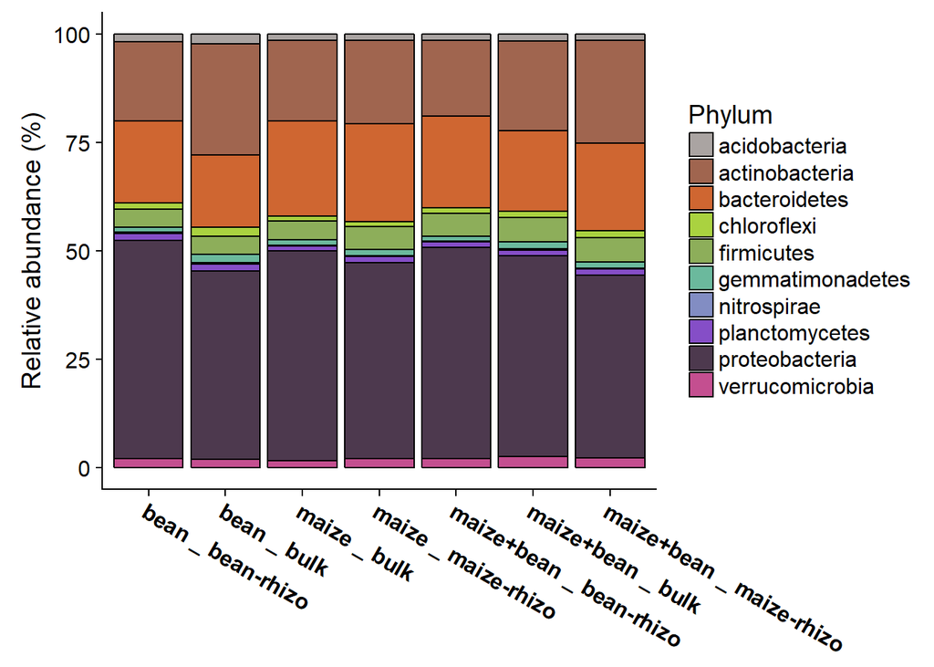

```r
#Normalizing again for easier visualization.
physeq_plm_concom_pct_top10_pct <-
  physeq_plm_concom_pct_top10 %>%
  transform_sample_counts(function(OTU) OTU/sum(OTU)*100 )

#Barplot showing the 10 most abundant OTU percentage according to conditions.
physeq_plm_concom_pct_top10_pct %>%
  plot_bar(fill = "Phylum",
         x = "concom")+
  theme(axis.text.x = element_text(angle = 330, size = 12, face = "bold"),
        axis.title.x = element_blank())+
  ylab(label = "Relative abundance (%)")+
  scale_fill_manual(values = c("#aaa4a2",
"#a0654f",
"#cf6631",
"#aad240",
"#8dae5a",
"#6bb99d",
"#828dc3",
"#854ec7",
"#4d394e",
"#c44f90"))
```

#### Classes

The same process applied to the class phylogenetic rank.

```r
#OTUs agglomerated at the Class level.
physeq_cls <-
  physeq %>%
  tax_glom(taxrank = "Class")

#Samples merged according to the "concom" factor (i.e. pooling OTUs from samples sharing the condition and compartment).
physeq_cls_concom <-
  physeq_cls %>%
  merge_samples("concom")

#merging the samples resulted in losing the information about the "concom" factor in the data frame, factor-level labels have been replaced by numeric values, here we put back labels for each level of the "concom" factor.
physeq_cls_concom@sam_data$concom = c("bean _ bean-rhizo", "bean _ bulk", "maize _ bulk", "maize _ maize-rhizo", "maize+bean _ bean-rhizo", "maize+bean _ bulk", "maize+bean _ maize-rhizo")

#Counts normalized by percentage.
physeq_cls_concom_pct <-
  physeq_cls_concom %>%
  transform_sample_counts(function(OTU) OTU/sum(OTU)*100 )

#Selecting the top10 OTUs based on percentage normalization.
physeq_cls_concom_pct_top10 <-
  prune_taxa(names(sort(taxa_sums(physeq_cls_concom_pct),
                        TRUE))[1:10], physeq_cls_concom_pct)

#Calculating the top10 OTU representation among conditions.
summary(rowSums(physeq_cls_concom_pct_top10@otu_table))
```

```
##    Min. 1st Qu.  Median    Mean 3rd Qu.    Max.
##   92.41   93.59   93.95   93.98   94.70   94.90
```

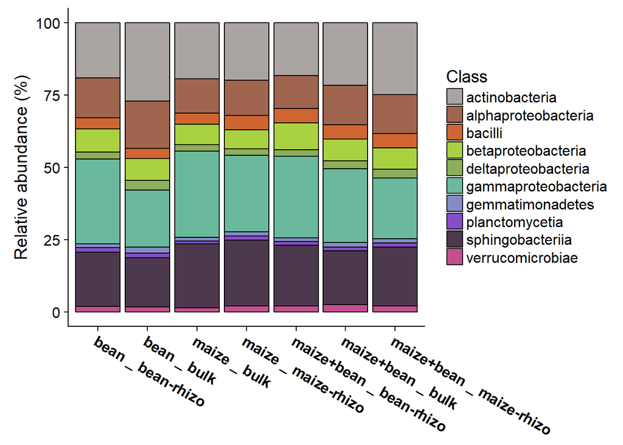

```r
#Normalizing again for easier visualization.
physeq_cls_concom_pct_top10_pct <-
  physeq_cls_concom_pct_top10 %>%
  transform_sample_counts(function(OTU) OTU/sum(OTU)*100 )

#Barplot showing the 10 most abundant OTU percentage according to conditions.
physeq_cls_concom_pct_top10_pct %>%
  plot_bar(fill = "Class",
         x = "concom")+
  theme(axis.text.x = element_text(angle = 330, size = 12, face = "bold"),
        axis.title.x = element_blank())+
  ylab(label = "Relative abundance (%)")+
  scale_fill_manual(values = c("#aaa4a2",
"#a0654f",
"#cf6631",
"#aad240",
"#8dae5a",
"#6bb99d",
"#828dc3",
"#854ec7",
"#4d394e",
"#c44f90"))
```

Still no tremendous differences. Especially for the monoculture versus polyculture rhizosphere.

#### Orders

```r
#OTUs agglomerated at the Order level.
physeq_odr <-
  physeq %>%
  tax_glom(taxrank = "Order")

#Samples merged according to the "concom" factor (i.e. pooling OTUs from samples sharing the condition and compartment).
physeq_odr_concom <-
  physeq_odr %>%
  merge_samples("concom")

#merging the samples resulted in losing the information about the "concom" factor in the data frame, factor-level labels have been replaced by numeric values, here we put back labels for each level of the "concom" factor.
physeq_odr_concom@sam_data$concom = c("bean _ bean-rhizo", "bean _ bulk", "maize _ bulk", "maize _ maize-rhizo", "maize+bean _ bean-rhizo", "maize+bean _ bulk", "maize+bean _ maize-rhizo")

#Counts normalized by percentage.
physeq_odr_concom_pct <-
  physeq_odr_concom %>%
  transform_sample_counts(function(OTU) OTU/sum(OTU)*100 )

#Selecting the top10 OTUs based on percentage normalization.
physeq_odr_concom_pct_top10 <-
  prune_taxa(names(sort(taxa_sums(physeq_odr_concom_pct),
                        TRUE))[1:10], physeq_odr_concom_pct)

#Calculating the top10 OTU representation among conditions.
summary(rowSums(physeq_odr_concom_pct_top10@otu_table))
```

```
##    Min. 1st Qu.  Median    Mean 3rd Qu.    Max.
##   80.41   83.35   84.33   84.32   85.97   86.89
```

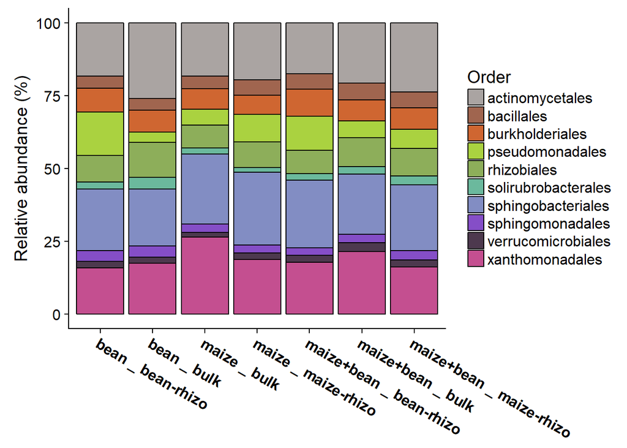

```r
#Normalizing again for easier visualization.
physeq_odr_concom_pct_top10_pct <-
  physeq_odr_concom_pct_top10 %>%
  transform_sample_counts(function(OTU) OTU/sum(OTU)*100 )

#Barplot showing the 10 most abundant OTU percentage according to conditions.
physeq_odr_concom_pct_top10_pct %>%
  plot_bar(fill = "Order",
         x = "concom")+
  theme(axis.text.x = element_text(angle = 330, size = 12, face = "bold"),
        axis.title.x = element_blank())+
  ylab(label = "Relative abundance (%)")+
  scale_fill_manual(values = c("#aaa4a2",
"#a0654f",
"#cf6631",
"#aad240",
"#8dae5a",
"#6bb99d",
"#828dc3",
"#854ec7",
"#4d394e",
"#c44f90"))
```

Still no tremendous differences at this taxonomic level. Not surprisingly, Pseudomonadales order proportion looks to be higher in the rhizosphere compartment than in the bulk soil, no matter the culture type.

#### Families

```r
#OTUs agglomerated at the Family level.
physeq_fmy <-
  physeq %>%
  tax_glom(taxrank = "Family")

#Samples merged according to the "concom" factor (i.e. pooling OTUs from samples sharing the condition and compartment).
physeq_fmy_concom <-
  physeq_fmy %>%
  merge_samples("concom")

#merging the samples resulted in losing the information about the "concom" factor in the data frame, factor-level labels have been replaced by numeric values, here we put back labels for each level of the "concom" factor.
physeq_fmy_concom@sam_data$concom = c("bean _ bean-rhizo", "bean _ bulk", "maize _ bulk", "maize _ maize-rhizo", "maize+bean _ bean-rhizo", "maize+bean _ bulk", "maize+bean _ maize-rhizo")

#Counts normalized by percentage.
physeq_fmy_concom_pct <-
  physeq_fmy_concom %>%
  transform_sample_counts(function(OTU) OTU/sum(OTU)*100 )

#Selecting the top10 OTUs based on percentage normalization.
physeq_fmy_concom_pct_top10 <-
  prune_taxa(names(sort(taxa_sums(physeq_fmy_concom_pct),
                        TRUE))[1:10], physeq_fmy_concom_pct)

#Calculating the top10 OTU representation among conditions.
summary(rowSums(physeq_fmy_concom_pct_top10@otu_table))
```

```
##    Min. 1st Qu.  Median    Mean 3rd Qu.    Max.
##   55.59   60.31   62.98   62.60   65.64   67.76
```

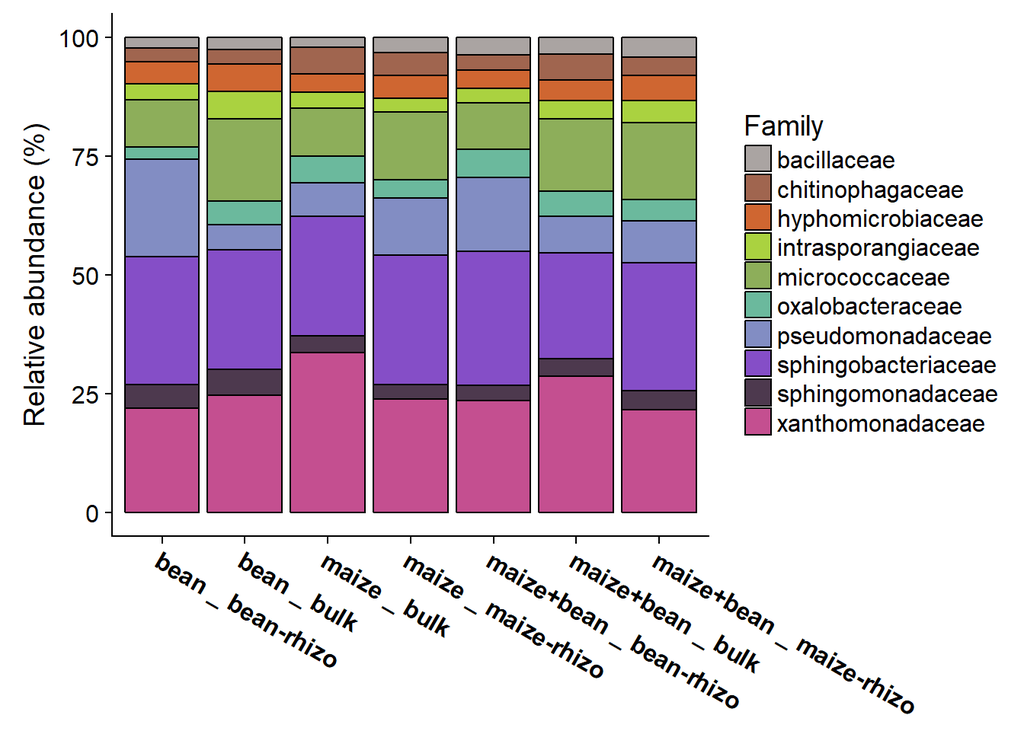

```r
#Normalizing again for easier visualization.
physeq_fmy_concom_pct_top10_pct <-
  physeq_fmy_concom_pct_top10 %>%
  transform_sample_counts(function(OTU) OTU/sum(OTU)*100 )

#Barplot showing the 10 most abundant OTU percentage according to conditions.
physeq_fmy_concom_pct_top10_pct %>%
  plot_bar(fill = "Family",
         x = "concom")+
  theme(axis.text.x = element_text(angle = 330, size = 12, face = "bold"),
        axis.title.x = element_blank())+
  ylab(label = "Relative abundance (%)")+
  scale_fill_manual(values = c("#aaa4a2",
"#a0654f",
"#cf6631",
"#aad240",
"#8dae5a",
"#6bb99d",
"#828dc3",
"#854ec7",
"#4d394e",
"#c44f90"))
```

Still no tremendous differences. Besides for the Pseudomonadaceae family between bean rhizosphere and bulk soil.

#### Genus

```r
#OTUs agglomerated at the Genus level.
physeq_gns <-
  physeq %>%
  tax_glom(taxrank = "Genus")

#Samples merged according to the "concom" factor (i.e. pooling OTUs from samples sharing the condition and compartment).
physeq_gns_concom <-
  physeq_gns %>%
  merge_samples("concom")

#merging the samples resulted in losing the information about the "concom" factor in the data frame, factor-level labels have been replaced by numeric values, here we put back labels for each level of the "concom" factor.
physeq_gns_concom@sam_data$concom = c("bean _ bean-rhizo", "bean _ bulk", "maize _ bulk", "maize _ maize-rhizo", "maize+bean _ bean-rhizo", "maize+bean _ bulk", "maize+bean _ maize-rhizo")

#Counts normalized by percentage.
physeq_gns_concom_pct <-
  physeq_gns_concom %>%
  transform_sample_counts(function(OTU) OTU/sum(OTU)*100 )

#Selecting the top10 OTUs based on percentage normalization.
physeq_gns_concom_pct_top10 <-
  prune_taxa(names(sort(taxa_sums(physeq_gns_concom_pct),
                        TRUE))[1:10], physeq_gns_concom_pct)

#Calculating the top10 OTU representation among conditions.
summary(rowSums(physeq_gns_concom_pct_top10@otu_table))
```

```
##    Min. 1st Qu.  Median    Mean 3rd Qu.    Max.
##   46.33   49.30   52.46   51.41   53.74   55.01
```

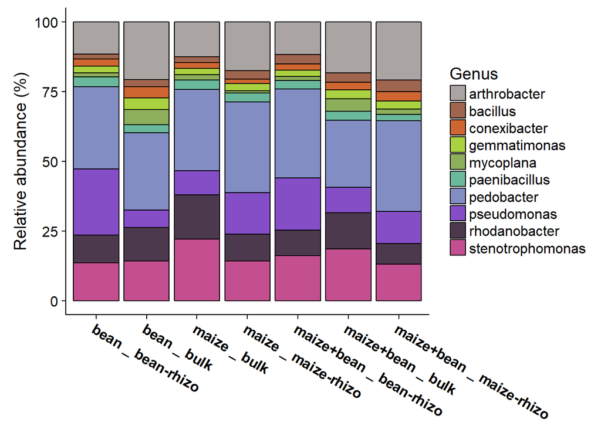

```r
#Normalizing again for easier visualization.
physeq_gns_concom_pct_top10_pct <-
  physeq_gns_concom_pct_top10 %>%
  transform_sample_counts(function(OTU) OTU/sum(OTU)*100 )

#Barplot showing the 10 most abundant OTU percentage according to conditions.
physeq_gns_concom_pct_top10_pct %>%
  plot_bar(fill = "Genus",
         x = "concom")+
  theme(axis.text.x = element_text(angle = 330, size = 12, face = "bold"),
        axis.title.x = element_blank())+
  ylab(label = "Relative abundance (%)")+
  scale_fill_manual(values = c("#aaa4a2",
"#a0654f",
"#cf6631",
"#aad240",
"#8dae5a",
"#6bb99d",
"#828dc3",
"#854ec7",
"#4d394e",
"#c44f90"))
```

The Pseudomonas genus proportion is higher within the bean rhizosphere condition than in any other condition. But still no pattern seems to differenciate polyculture from monoculture rhizo-microbiome.

#### Species

```r
#OTUs agglomerated at the Species level.
physeq_sps <-
  physeq %>%
  tax_glom(taxrank = "Species")

#Samples merged according to the "concom" factor (i.e. pooling OTUs from samples sharing the condition and compartment).
physeq_sps_concom <-
  physeq_sps %>%
  merge_samples("concom")

#merging the samples resulted in losing the information about the "concom" factor in the data frame, factor-level labels have been replaced by numeric values, here we put back labels for each level of the "concom" factor.
physeq_sps_concom@sam_data$concom = c("bean _ bean-rhizo", "bean _ bulk", "maize _ bulk", "maize _ maize-rhizo", "maize+bean _ bean-rhizo", "maize+bean _ bulk", "maize+bean _ maize-rhizo")

#Counts normalized by percentage.
physeq_sps_concom_pct <-
  physeq_sps_concom %>%
  transform_sample_counts(function(OTU) OTU/sum(OTU)*100 )

#Selecting the top10 OTUs based on percentage normalization.
physeq_sps_concom_pct_top10 <-
  prune_taxa(names(sort(taxa_sums(physeq_sps_concom_pct),
                        TRUE))[1:10], physeq_sps_concom_pct)

#Calculating the top10 OTU representation among conditions.
summary(rowSums(physeq_sps_concom_pct_top10@otu_table))
```

```
##    Min. 1st Qu.  Median    Mean 3rd Qu.    Max.
##   29.66   33.96   35.25   35.05   37.05   38.44
```

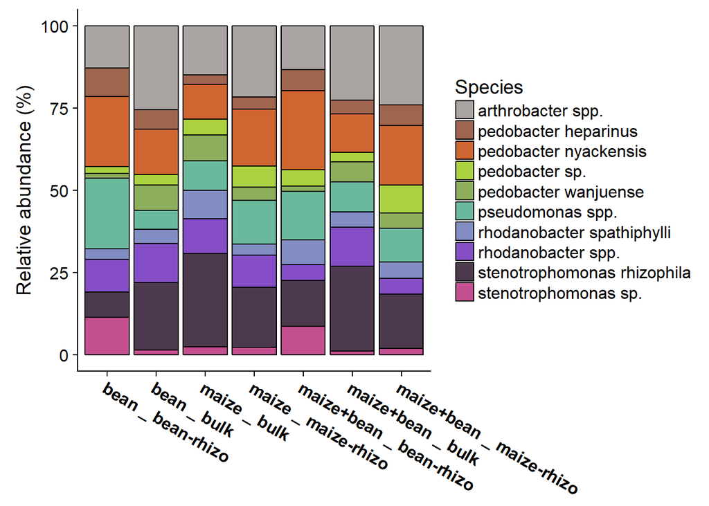

```r
#Normalizing again for easier visualization.
physeq_sps_concom_pct_top10_pct <-
  physeq_sps_concom_pct_top10 %>%
  transform_sample_counts(function(OTU) OTU/sum(OTU)*100 )

#Barplot showing the 10 most abundant OTU percentage according to conditions.
physeq_sps_concom_pct_top10_pct %>%
  plot_bar(fill = "Species",
         x = "concom")+
  theme(axis.text.x = element_text(angle = 330, size = 12, face = "bold"),
        axis.title.x = element_blank())+
  ylab(label = "Relative abundance (%)")+
  scale_fill_manual(values = c("#aaa4a2",
"#a0654f",
"#cf6631",
"#aad240",
"#8dae5a",
"#6bb99d",
"#828dc3",
"#854ec7",
"#4d394e",
"#c44f90"))
```

Still no clear patern. Although we can observe more differences for low taxonomical rank. Meaning that the effect of polyculture could be specie or even strain specific.

### Filtering low variance

Another way to visualize a potential effect of polyculture on the rhizo-microbiome is to filter the low variance OTUs. So only the highly variant OTUs between conditions will be displayed.

#### Phylum

##### Var > 0.1

```r
#var > 0.1 : Selecting OTUs which show a variance value superior to 0.1.
physeq_plm_concom_pct_highVar0.1 =
  filter_taxa(physeq_plm_concom_pct,
              function(x) var(x) > 0.1, TRUE)

#So We can take a look at the species names
physeq_plm_concom_pct_highVar0.1@tax_table
```

```
## Taxonomy Table:     [6 taxa by 7 taxonomic ranks]:
##         Domain     Phylum            Class Order Family Genus Species
## OTU4486 "bacteria" "firmicutes"      NA    NA    NA     NA    NA
## OTU7    "bacteria" "proteobacteria"  NA    NA    NA     NA    NA
## OTU1    "bacteria" "actinobacteria"  NA    NA    NA     NA    NA
## OTU129  "bacteria" "acidobacteria"   NA    NA    NA     NA    NA
## OTU46   "bacteria" "verrucomicrobia" NA    NA    NA     NA    NA
## OTU6    "bacteria" "bacteroidetes"   NA    NA    NA     NA    NA
```

```r
#Creating an atomic vector containing the names of those OTUs
physeq_plm_concom_names_highVar0.1 <-
  as.data.frame(physeq_plm_concom_pct_highVar0.1@tax_table)

#We can now exctract those OTus from the unormalized sequences-data set (still regrouped by Phylum and conditions)
physeq_plm_concom_highVar0.1 <- subset_taxa(physeq_plm_concom, Phylum %in% physeq_plm_concom_names_highVar0.1$Phylum)

#Take a look at the names (those we wanted, we made it !)
physeq_plm_concom_highVar0.1@tax_table
```

```
## Taxonomy Table:     [6 taxa by 7 taxonomic ranks]:
##         Domain     Phylum            Class Order Family Genus Species
## OTU4486 "bacteria" "firmicutes"      NA    NA    NA     NA    NA
## OTU7    "bacteria" "proteobacteria"  NA    NA    NA     NA    NA
## OTU1    "bacteria" "actinobacteria"  NA    NA    NA     NA    NA
## OTU129  "bacteria" "acidobacteria"   NA    NA    NA     NA    NA
## OTU46   "bacteria" "verrucomicrobia" NA    NA    NA     NA    NA
## OTU6    "bacteria" "bacteroidetes"   NA    NA    NA     NA    NA
```

```r
#Check the number of sequences (huge variance can results by presence of 0, which is something we don't want), but here there is no zero sequence OTU, grand !
physeq_plm_concom_highVar0.1@otu_table
```

```
## OTU Table:          [6 taxa and 7 samples]
##                      taxa are columns
##                          OTU4486   OTU7   OTU1 OTU129 OTU46   OTU6
## bean _ bean-rhizo          17184 205538  74135   7127  8494  77314
## bean _ bulk                17831 186984 109774   9617  8099  71916
## maize _ bulk               24770 277767 107095   7645  9128 126131
## maize _ maize-rhizo        33666 287760 121900   9082 13700 144669
## maize+bean _ bean-rhizo    40486 368969 133589   9994 16547 160708
## maize+bean _ bulk          43866 362403 162136  12131 20666 145709
## maize+bean _ maize-rhizo   40816 308896 173510  10254 16512 148931
```

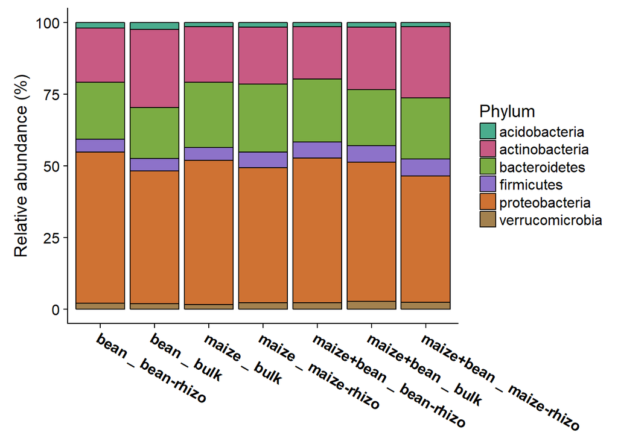

```r
#Normalizing the sequences per percentages for visual comparison.
physeq_plm_concom_highVar0.1_pct <-
  physeq_plm_concom_highVar0.1 %>%
  transform_sample_counts(function(OTU) OTU/sum(OTU)*100 )

#Bar_plot the datas (relative abundance of the 6 most variating species within 7 conditions)
physeq_plm_concom_highVar0.1_pct %>%
  plot_bar(fill = "Phylum",
         x = "concom")+
  theme(axis.text.x = element_text(angle = 330, size = 12, face = "bold"),
        axis.title.x = element_blank())+
  ylab(label = "Relative abundance (%)")+
  scale_fill_manual(values = c("#4aac8d",
"#c85a83",
"#7bac43",
"#8d72c9",
"#cf7233",
"#a3814e"))
```

At this level, even the most variating OTUs do not display marked differences.

#### Classes

##### Var > 0.1

```r
physeq_cls_concom_pct_highVar0.1 =
  filter_taxa(physeq_cls_concom_pct,
              function(x) var(x) > 0.1, TRUE)

physeq_cls_concom_pct_highVar0.1@tax_table
```

```
## Taxonomy Table:     [8 taxa by 7 taxonomic ranks]:
##         Domain     Phylum            Class                 Order Family
## OTU4486 "bacteria" "firmicutes"      "bacilli"             NA    NA
## OTU7    "bacteria" "proteobacteria"  "gammaproteobacteria" NA    NA
## OTU1    "bacteria" "actinobacteria"  "actinobacteria"      NA    NA
## OTU57   "bacteria" "proteobacteria"  "deltaproteobacteria" NA    NA
## OTU30   "bacteria" "proteobacteria"  "betaproteobacteria"  NA    NA
## OTU46   "bacteria" "verrucomicrobia" "verrucomicrobiae"    NA    NA
## OTU6    "bacteria" "bacteroidetes"   "sphingobacteriia"    NA    NA
## OTU11   "bacteria" "proteobacteria"  "alphaproteobacteria" NA    NA
##         Genus Species
## OTU4486 NA    NA
## OTU7    NA    NA
## OTU1    NA    NA
## OTU57   NA    NA
## OTU30   NA    NA
## OTU46   NA    NA
## OTU6    NA    NA
## OTU11   NA    NA
```

```r
physeq_cls_concom_names_highVar0.1 <-
  as.data.frame(physeq_cls_concom_pct_highVar0.1@tax_table)

physeq_cls_concom_highVar0.1 <- subset_taxa(physeq_cls_concom, Class %in% physeq_cls_concom_names_highVar0.1$Class)

physeq_cls_concom_highVar0.1@tax_table
```

```
## Taxonomy Table:     [8 taxa by 7 taxonomic ranks]:
##         Domain     Phylum            Class                 Order Family
## OTU4486 "bacteria" "firmicutes"      "bacilli"             NA    NA
## OTU7    "bacteria" "proteobacteria"  "gammaproteobacteria" NA    NA
## OTU1    "bacteria" "actinobacteria"  "actinobacteria"      NA    NA
## OTU57   "bacteria" "proteobacteria"  "deltaproteobacteria" NA    NA
## OTU30   "bacteria" "proteobacteria"  "betaproteobacteria"  NA    NA
## OTU46   "bacteria" "verrucomicrobia" "verrucomicrobiae"    NA    NA
## OTU6    "bacteria" "bacteroidetes"   "sphingobacteriia"    NA    NA
## OTU11   "bacteria" "proteobacteria"  "alphaproteobacteria" NA    NA
##         Genus Species
## OTU4486 NA    NA
## OTU7    NA    NA
## OTU1    NA    NA
## OTU57   NA    NA
## OTU30   NA    NA
## OTU46   NA    NA
## OTU6    NA    NA
## OTU11   NA    NA
```

```r
physeq_cls_concom_highVar0.1@otu_table
```

```
## OTU Table:          [8 taxa and 7 samples]
##                      taxa are columns
##                          OTU4486   OTU7   OTU1 OTU57 OTU30 OTU46   OTU6
## bean _ bean-rhizo          14399 112300  73035  9434 30790  7706  71842
## bean _ bulk                14158  78756 107780 13136 30115  7232  67857
## maize _ bulk               21450 162839 105312 11481 38737  8182 120145
## maize _ maize-rhizo        29899 160735 120308 13279 40194 12622 138408
## maize+bean _ bean-rhizo    34693 202802 131514 16877 67196 15255 151395
## maize+bean _ bulk          37803 187566 159153 20252 54571 19487 136985
## maize+bean _ maize-rhizo   34117 144557 170547 20290 51140 15036 139825
##                          OTU11
## bean _ bean-rhizo        52998
## bean _ bulk              64960
## maize _ bulk             64695
## maize _ maize-rhizo      73543
## maize+bean _ bean-rhizo  82066
## maize+bean _ bulk        99944
## maize+bean _ maize-rhizo 92873
```

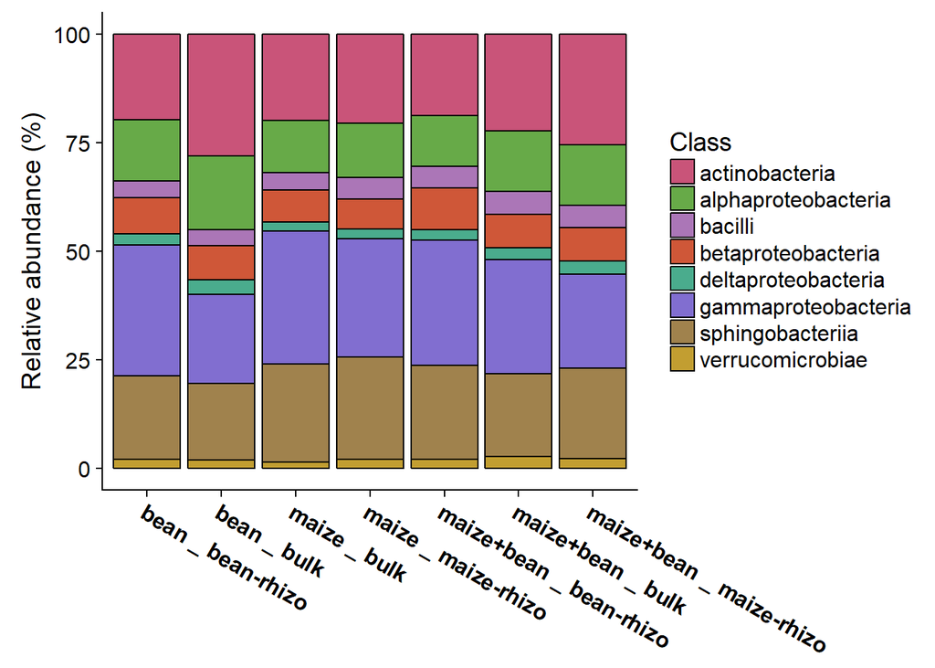

```r
physeq_cls_concom_highVar0.1_pct <-
  physeq_cls_concom_highVar0.1 %>%
  transform_sample_counts(function(OTU) OTU/sum(OTU)*100 )

#Bar_plot the datas (relative abundance of the most variating OTUs within 7 conditions)
physeq_cls_concom_highVar0.1_pct %>%
  plot_bar(fill = "Class",
         x = "concom")+
  theme(axis.text.x = element_text(angle = 330, size = 12, face = "bold"),
        axis.title.x = element_blank())+
  ylab(label = "Relative abundance (%)")+
  scale_fill_manual(values = c("#c95479",
"#67aa48",
"#ab76b7",
"#cf5738",
"#4aac8d",
"#816ed0",
"#a0824d",
"#c29e31"))
```

The taxonomical structure still quite similar between conditions, except for the bean bulk soil which contains a higher proportion of the Actinobacteria Class.

#### Orders

##### Var > 0.1

```r
physeq_odr_concom_pct_highVar0.1 =
  filter_taxa(physeq_odr_concom_pct,
              function(x) var(x) > 0.1, TRUE)

physeq_odr_concom_pct_highVar0.1@tax_table
```

```
## Taxonomy Table:     [12 taxa by 7 taxonomic ranks]:
##         Domain     Phylum            Class
## OTU4486 "bacteria" "firmicutes"      "bacilli"
## OTU42   "bacteria" "proteobacteria"  "alphaproteobacteria"
## OTU7    "bacteria" "proteobacteria"  "gammaproteobacteria"
## OTU1    "bacteria" "actinobacteria"  "actinobacteria"
## OTU33   "bacteria" "proteobacteria"  "gammaproteobacteria"
## OTU3    "bacteria" "proteobacteria"  "gammaproteobacteria"
## OTU23   "bacteria" "proteobacteria"  "gammaproteobacteria"
## OTU30   "bacteria" "proteobacteria"  "betaproteobacteria"
## OTU46   "bacteria" "verrucomicrobia" "verrucomicrobiae"
## OTU72   "bacteria" "actinobacteria"  "actinobacteria"
## OTU6    "bacteria" "bacteroidetes"   "sphingobacteriia"
## OTU11   "bacteria" "proteobacteria"  "alphaproteobacteria"
##         Order                 Family Genus Species
## OTU4486 "bacillales"          NA     NA    NA
## OTU42   "sphingomonadales"    NA     NA    NA
## OTU7    "xanthomonadales"     NA     NA    NA
## OTU1    "actinomycetales"     NA     NA    NA
## OTU33   "vibrionales"         NA     NA    NA
## OTU3    "pseudomonadales"     NA     NA    NA
## OTU23   "enterobacteriales"   NA     NA    NA
## OTU30   "burkholderiales"     NA     NA    NA
## OTU46   "verrucomicrobiales"  NA     NA    NA
## OTU72   "solirubrobacterales" NA     NA    NA
## OTU6    "sphingobacteriales"  NA     NA    NA
## OTU11   "rhizobiales"         NA     NA    NA
```

```r
physeq_odr_concom_names_highVar0.1 <-
  as.data.frame(physeq_odr_concom_pct_highVar0.1@tax_table)

physeq_odr_concom_highVar0.1 <- subset_taxa(physeq_odr_concom, Order %in% physeq_odr_concom_names_highVar0.1$Order)

physeq_odr_concom_highVar0.1@tax_table
```

```
## Taxonomy Table:     [12 taxa by 7 taxonomic ranks]:
##         Domain     Phylum            Class
## OTU4486 "bacteria" "firmicutes"      "bacilli"
## OTU42   "bacteria" "proteobacteria"  "alphaproteobacteria"
## OTU7    "bacteria" "proteobacteria"  "gammaproteobacteria"
## OTU1    "bacteria" "actinobacteria"  "actinobacteria"
## OTU33   "bacteria" "proteobacteria"  "gammaproteobacteria"
## OTU3    "bacteria" "proteobacteria"  "gammaproteobacteria"
## OTU23   "bacteria" "proteobacteria"  "gammaproteobacteria"
## OTU30   "bacteria" "proteobacteria"  "betaproteobacteria"
## OTU46   "bacteria" "verrucomicrobia" "verrucomicrobiae"
## OTU72   "bacteria" "actinobacteria"  "actinobacteria"
## OTU6    "bacteria" "bacteroidetes"   "sphingobacteriia"
## OTU11   "bacteria" "proteobacteria"  "alphaproteobacteria"
##         Order                 Family Genus Species
## OTU4486 "bacillales"          NA     NA    NA
## OTU42   "sphingomonadales"    NA     NA    NA
## OTU7    "xanthomonadales"     NA     NA    NA
## OTU1    "actinomycetales"     NA     NA    NA
## OTU33   "vibrionales"         NA     NA    NA
## OTU3    "pseudomonadales"     NA     NA    NA
## OTU23   "enterobacteriales"   NA     NA    NA
## OTU30   "burkholderiales"     NA     NA    NA
## OTU46   "verrucomicrobiales"  NA     NA    NA
## OTU72   "solirubrobacterales" NA     NA    NA
## OTU6    "sphingobacteriales"  NA     NA    NA
## OTU11   "rhizobiales"         NA     NA    NA
```

```r
physeq_odr_concom_highVar0.1@otu_table
```

```
## OTU Table:          [12 taxa and 7 samples]
##                      taxa are columns
##                          OTU4486 OTU42   OTU7   OTU1 OTU33  OTU3 OTU23
## bean _ bean-rhizo          14379 12436  53698  61784  4147 50376  2629
## bean _ bulk                14119 13703  60411  89793  3715 12530  1055
## maize _ bulk               21390 14455 132183  91258   599 27725  1212
## maize _ maize-rhizo        29858 14524 104190 107934   652 52029  2129
## maize+bean _ bean-rhizo    34636 16655 115373 112465   247 75324  9161
## maize+bean _ bulk          37739 19408 142839 136654  2873 38042  1856
## maize+bean _ maize-rhizo   34064 19149  99913 145465   503 40649  1107
##                          OTU30 OTU46 OTU72   OTU6 OTU11
## bean _ bean-rhizo        27584  7706  8275  71842 31263
## bean _ bulk              25805  7232 13620  67857 41549
## maize _ bulk             35061  8182 10527 120145 38775
## maize _ maize-rhizo      36021 12622  8982 138408 49496
## maize+bean _ bean-rhizo  60793 15255 14007 151395 52337
## maize+bean _ bulk        48302 19487 16750 136985 65615
## maize+bean _ maize-rhizo 45066 15036 18732 139825 58553
```

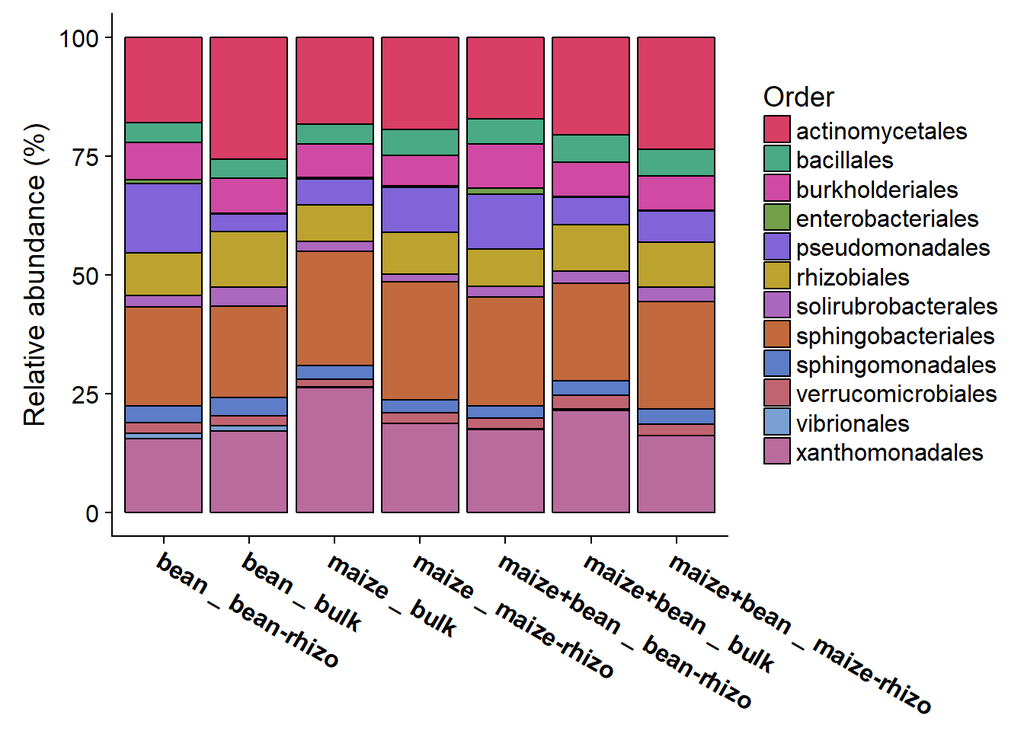

```r
physeq_odr_concom_highVar0.1_pct <-
  physeq_odr_concom_highVar0.1 %>%
  transform_sample_counts(function(OTU) OTU/sum(OTU)*100 )

physeq_odr_concom_highVar0.1_pct %>%
  plot_bar(fill = "Order",
         x = "concom")+
  theme(axis.text.x = element_text(angle = 330, size = 12, face = "bold"),
        axis.title.x = element_blank())+
  ylab(label = "Relative abundance (%)")+
  scale_fill_manual(values = c("#d93e64",
"#4aaa86",
"#d04aa3",
"#739f4b",
"#8064d8",
"#bca32f",
"#ac67bf",
"#c26a3e",
"#5d7dc8",
"#c16472",
"#7aa0d3",
"#b96b9e"))
```

No clear differences when comparing monoculture and polyculture rhizo-microbiome according to the corresponding bulk soil.

#### Families

##### Var > 0.5

```r
physeq_fmy_concom_pct_highVar0.5 =
  filter_taxa(physeq_fmy_concom_pct,
              function(x) var(x) > 0.5, TRUE)

physeq_fmy_concom_pct_highVar0.5@tax_table
```

```
## Taxonomy Table:     [7 taxa by 7 taxonomic ranks]:
##       Domain     Phylum           Class
## OTU7  "bacteria" "proteobacteria" "gammaproteobacteria"
## OTU1  "bacteria" "actinobacteria" "actinobacteria"
## OTU3  "bacteria" "proteobacteria" "gammaproteobacteria"
## OTU30 "bacteria" "proteobacteria" "betaproteobacteria"
## OTU6  "bacteria" "bacteroidetes"  "sphingobacteriia"
## OTU11 "bacteria" "proteobacteria" "alphaproteobacteria"
## OTU87 "bacteria" "bacteroidetes"  "sphingobacteriia"
##       Order                Family                Genus Species
## OTU7  "xanthomonadales"    "xanthomonadaceae"    NA    NA
## OTU1  "actinomycetales"    "micrococcaceae"      NA    NA
## OTU3  "pseudomonadales"    "pseudomonadaceae"    NA    NA
## OTU30 "burkholderiales"    "oxalobacteraceae"    NA    NA
## OTU6  "sphingobacteriales" "sphingobacteriaceae" NA    NA
## OTU11 "rhizobiales"        "brucellaceae"        NA    NA
## OTU87 "sphingobacteriales" "chitinophagaceae"    NA    NA
```

```r
physeq_fmy_concom_names_highVar0.5 <-
  as.data.frame(physeq_fmy_concom_pct_highVar0.5@tax_table)

physeq_fmy_concom_highVar0.5 <- subset_taxa(physeq_fmy_concom, Family %in% physeq_fmy_concom_names_highVar0.5$Family)

physeq_fmy_concom_highVar0.5@tax_table
```

```
## Taxonomy Table:     [7 taxa by 7 taxonomic ranks]:
##       Domain     Phylum           Class
## OTU7  "bacteria" "proteobacteria" "gammaproteobacteria"
## OTU1  "bacteria" "actinobacteria" "actinobacteria"
## OTU3  "bacteria" "proteobacteria" "gammaproteobacteria"
## OTU30 "bacteria" "proteobacteria" "betaproteobacteria"
## OTU6  "bacteria" "bacteroidetes"  "sphingobacteriia"
## OTU11 "bacteria" "proteobacteria" "alphaproteobacteria"
## OTU87 "bacteria" "bacteroidetes"  "sphingobacteriia"
##       Order                Family                Genus Species
## OTU7  "xanthomonadales"    "xanthomonadaceae"    NA    NA
## OTU1  "actinomycetales"    "micrococcaceae"      NA    NA
## OTU3  "pseudomonadales"    "pseudomonadaceae"    NA    NA
## OTU30 "burkholderiales"    "oxalobacteraceae"    NA    NA
## OTU6  "sphingobacteriales" "sphingobacteriaceae" NA    NA
## OTU11 "rhizobiales"        "brucellaceae"        NA    NA
## OTU87 "sphingobacteriales" "chitinophagaceae"    NA    NA
```

```r
physeq_fmy_concom_highVar0.5@otu_table
```

```
## OTU Table:          [7 taxa and 7 samples]
##                      taxa are columns
##                            OTU7  OTU1  OTU3 OTU30   OTU6 OTU11 OTU87
## bean _ bean-rhizo         52906 23793 49377  6290  64963  3477  6837
## bean _ bulk               59310 41369 12441 11916  60314 11188  7534
## maize _ bulk             131142 39716 27692 21711  97725  6268 22400
## maize _ maize-rhizo      103109 61484 51956 16699 117608  2611 20766
## maize+bean _ bean-rhizo  114130 47306 75180 28792 136335  6703 14978
## maize+bean _ bulk        141553 75107 37970 26176 110012 19385 26957
## maize+bean _ maize-rhizo  98579 73777 40384 20258 122235  6888 17542
```

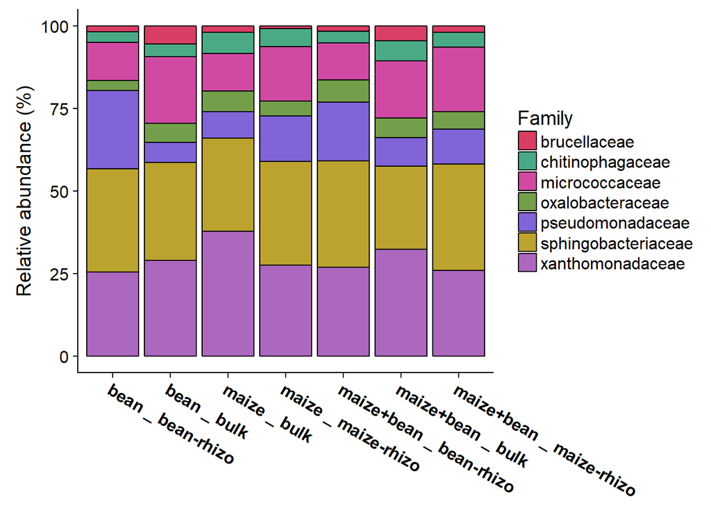

```r
physeq_fmy_concom_highVar0.5_pct <-
  physeq_fmy_concom_highVar0.5 %>%
  transform_sample_counts(function(OTU) OTU/sum(OTU)*100 )

physeq_fmy_concom_highVar0.5_pct %>%
  plot_bar(fill = "Family",
         x = "concom")+
  theme(axis.text.x = element_text(angle = 330, size = 12, face = "bold"),
        axis.title.x = element_blank())+
  ylab(label = "Relative abundance (%)")+
  scale_fill_manual(values = c("#d93e64",
"#4aaa86",
"#d04aa3",
"#739f4b",
"#8064d8",
"#bca32f",
"#ac67bf",
"#c26a3e",
"#5d7dc8",
"#c16472",
"#7aa0d3",
"#b96b9e"))
```

Still no clear differences when comparing monoculture and polyculture rhizo-microbiome according to the corresponding bulk soil.

#### Genus

##### Var > 0.5

```r
#var > 0.5 : all is the same, beside we put the variance thershold up to 0.5

#Normalized sequences are regrouped by species and conditions (i.e different plant's rhizospheres and bulk soils),
physeq_gns_concom_pct_highVar0.5 =
  filter_taxa(physeq_gns_concom_pct,
              function(x) var(x) > 0.5, TRUE)

#So We can take a look at the species names
physeq_gns_concom_pct_highVar0.5@tax_table
```

```
## Taxonomy Table:     [7 taxa by 7 taxonomic ranks]:
##          Domain     Phylum           Class
## OTU10587 "bacteria" "proteobacteria" "gammaproteobacteria"
## OTU7     "bacteria" "proteobacteria" "gammaproteobacteria"
## OTU1     "bacteria" "actinobacteria" "actinobacteria"
## OTU3     "bacteria" "proteobacteria" "gammaproteobacteria"
## OTU6     "bacteria" "bacteroidetes"  "sphingobacteriia"
## OTU5     "bacteria" "proteobacteria" "gammaproteobacteria"
## OTU11    "bacteria" "proteobacteria" "alphaproteobacteria"
##          Order                Family                Genus
## OTU10587 "xanthomonadales"    "xanthomonadaceae"    "stenotrophomonas"
## OTU7     "xanthomonadales"    "xanthomonadaceae"    "rhodanobacter"
## OTU1     "actinomycetales"    "micrococcaceae"      "arthrobacter"
## OTU3     "pseudomonadales"    "pseudomonadaceae"    "pseudomonas"
## OTU6     "sphingobacteriales" "sphingobacteriaceae" "pedobacter"
## OTU5     "xanthomonadales"    "xanthomonadaceae"    "lysobacter"
## OTU11    "rhizobiales"        "brucellaceae"        "mycoplana"
##          Species
## OTU10587 NA
## OTU7     NA
## OTU1     NA
## OTU3     NA
## OTU6     NA
## OTU5     NA
## OTU11    NA
```

```r
#Creating an atomic vector containing the names of those species
physeq_gns_concom_names_highVar0.5 <-
  as.data.frame(physeq_gns_concom_pct_highVar0.5@tax_table)

#We can now exctract those species from the unormalized sequences-data set (still regrouped by species and conditions)
physeq_gns_concom_highVar0.5 <- subset_taxa(physeq_gns_concom, Genus %in% physeq_gns_concom_names_highVar0.5$Genus)

#Take a look at the names (those we wanted, we made it !)
physeq_gns_concom_highVar0.5@tax_table
```

```
## Taxonomy Table:     [7 taxa by 7 taxonomic ranks]:
##          Domain     Phylum           Class
## OTU10587 "bacteria" "proteobacteria" "gammaproteobacteria"
## OTU7     "bacteria" "proteobacteria" "gammaproteobacteria"
## OTU1     "bacteria" "actinobacteria" "actinobacteria"
## OTU3     "bacteria" "proteobacteria" "gammaproteobacteria"
## OTU6     "bacteria" "bacteroidetes"  "sphingobacteriia"
## OTU5     "bacteria" "proteobacteria" "gammaproteobacteria"
## OTU11    "bacteria" "proteobacteria" "alphaproteobacteria"
##          Order                Family                Genus
## OTU10587 "xanthomonadales"    "xanthomonadaceae"    "stenotrophomonas"
## OTU7     "xanthomonadales"    "xanthomonadaceae"    "rhodanobacter"
## OTU1     "actinomycetales"    "micrococcaceae"      "arthrobacter"
## OTU3     "pseudomonadales"    "pseudomonadaceae"    "pseudomonas"
## OTU6     "sphingobacteriales" "sphingobacteriaceae" "pedobacter"
## OTU5     "xanthomonadales"    "xanthomonadaceae"    "lysobacter"
## OTU11    "rhizobiales"        "brucellaceae"        "mycoplana"
##          Species
## OTU10587 NA
## OTU7     NA
## OTU1     NA
## OTU3     NA
## OTU6     NA
## OTU5     NA
## OTU11    NA
```

```r
#Check the number of sequences (huge variance can results by presence of 0, which is something we don't want), but here there is no zero sequence OTU, so it's grand !
physeq_gns_concom_highVar0.5@otu_table
```

```
## OTU Table:          [7 taxa and 7 samples]
##                      taxa are columns
##                          OTU10587  OTU7  OTU1  OTU3   OTU6  OTU5 OTU11
## bean _ bean-rhizo           28164 20570 23673 49370  61088  1237  3005
## bean _ bulk                 28585 23931 41240 12436  55537  3211 10646
## maize _ bulk                70275 49818 39524 27691  91919  4156  6184
## maize _ maize-rhizo         50134 33548 61133 51946 113569 13416  2516
## maize+bean _ bean-rhizo     65075 36860 47013 75139 127993  5257  6082
## maize+bean _ bulk           76462 53480 74787 37961  98941  5292 19008
## maize+bean _ maize-rhizo    46494 26083 73458 40330 114904 18032  6511
```

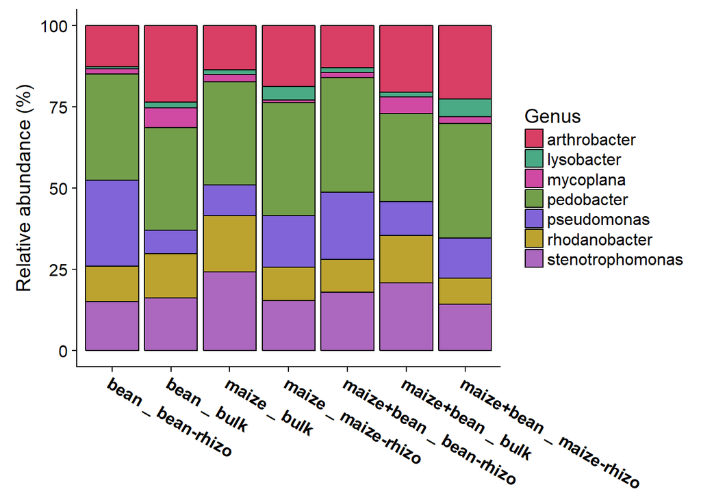

```r
#Normalizing the sequences for visual comparison.
physeq_gns_concom_highVar0.5_pct <-
  physeq_gns_concom_highVar0.5 %>%
  transform_sample_counts(function(OTU) OTU/sum(OTU)*100 )

#Bar_plot the datas (relative abundance of the 6 most variating species within 7 conditions)
physeq_gns_concom_highVar0.5_pct %>%
  plot_bar(fill = "Genus",
         x = "concom")+
  theme(axis.text.x = element_text(angle = 330, size = 12, face = "bold"),
        axis.title.x = element_blank())+
  ylab(label = "Relative abundance (%)")+
  scale_fill_manual(values = c("#d93e64",
"#4aaa86",
"#d04aa3",
"#739f4b",
"#8064d8",
"#bca32f",
"#ac67bf",
"#c26a3e",
"#5d7dc8",
"#c16472",
"#7aa0d3",
"#b96b9e"))
```

Still no clear differences when comparing monoculture and polyculture rhizo-microbiome according to the corresponding bulk soil.

#### Species

##### Var > 0.5

```r
physeq_sps_concom_pct_highVar0.5 =
  filter_taxa(physeq_sps_concom_pct,
              function(x) var(x) > 0.5, TRUE)

physeq_sps_concom_pct_highVar0.5@tax_table
```

```
## Taxonomy Table:     [11 taxa by 7 taxonomic ranks]:
##          Domain     Phylum           Class
## OTU4056  "bacteria" "proteobacteria" "gammaproteobacteria"
## OTU10587 "bacteria" "proteobacteria" "gammaproteobacteria"
## OTU826   "bacteria" "bacteroidetes"  "sphingobacteriia"
## OTU10    "bacteria" "proteobacteria" "gammaproteobacteria"
## OTU7     "bacteria" "proteobacteria" "gammaproteobacteria"
## OTU1     "bacteria" "actinobacteria" "actinobacteria"
## OTU9     "bacteria" "bacteroidetes"  "sphingobacteriia"
## OTU3     "bacteria" "proteobacteria" "gammaproteobacteria"
## OTU31    "bacteria" "bacteroidetes"  "sphingobacteriia"
## OTU6     "bacteria" "bacteroidetes"  "sphingobacteriia"
## OTU11    "bacteria" "proteobacteria" "alphaproteobacteria"
##          Order                Family                Genus
## OTU4056  "xanthomonadales"    "xanthomonadaceae"    "rhodanobacter"
## OTU10587 "xanthomonadales"    "xanthomonadaceae"    "stenotrophomonas"
## OTU826   "sphingobacteriales" "sphingobacteriaceae" "pedobacter"
## OTU10    "xanthomonadales"    "xanthomonadaceae"    "stenotrophomonas"
## OTU7     "xanthomonadales"    "xanthomonadaceae"    "rhodanobacter"
## OTU1     "actinomycetales"    "micrococcaceae"      "arthrobacter"
## OTU9     "sphingobacteriales" "sphingobacteriaceae" "pedobacter"
## OTU3     "pseudomonadales"    "pseudomonadaceae"    "pseudomonas"
## OTU31    "sphingobacteriales" "sphingobacteriaceae" "pedobacter"
## OTU6     "sphingobacteriales" "sphingobacteriaceae" "pedobacter"
## OTU11    "rhizobiales"        "brucellaceae"        "mycoplana"
##          Species
## OTU4056  "rhodanobacter spathiphylli"
## OTU10587 "stenotrophomonas rhizophila"
## OTU826   "pedobacter daejeonensis"
## OTU10    "stenotrophomonas sp."
## OTU7     "rhodanobacter spp."
## OTU1     "arthrobacter spp."
## OTU9     "pedobacter wanjuense"
## OTU3     "pseudomonas spp."
## OTU31    "pedobacter sp."
## OTU6     "pedobacter nyackensis"
## OTU11    "mycoplana spp."
```

```r
physeq_sps_concom_names_highVar0.5 <-
  as.data.frame(physeq_sps_concom_pct_highVar0.5@tax_table)

physeq_sps_concom_highVar0.5 <- subset_taxa(physeq_sps_concom, Species %in% physeq_sps_concom_names_highVar0.5$Species)

physeq_sps_concom_highVar0.5@tax_table
```

```
## Taxonomy Table:     [11 taxa by 7 taxonomic ranks]:
##          Domain     Phylum           Class
## OTU4056  "bacteria" "proteobacteria" "gammaproteobacteria"
## OTU10587 "bacteria" "proteobacteria" "gammaproteobacteria"
## OTU826   "bacteria" "bacteroidetes"  "sphingobacteriia"
## OTU10    "bacteria" "proteobacteria" "gammaproteobacteria"
## OTU7     "bacteria" "proteobacteria" "gammaproteobacteria"
## OTU1     "bacteria" "actinobacteria" "actinobacteria"
## OTU9     "bacteria" "bacteroidetes"  "sphingobacteriia"
## OTU3     "bacteria" "proteobacteria" "gammaproteobacteria"
## OTU31    "bacteria" "bacteroidetes"  "sphingobacteriia"
## OTU6     "bacteria" "bacteroidetes"  "sphingobacteriia"
## OTU11    "bacteria" "proteobacteria" "alphaproteobacteria"
##          Order                Family                Genus
## OTU4056  "xanthomonadales"    "xanthomonadaceae"    "rhodanobacter"
## OTU10587 "xanthomonadales"    "xanthomonadaceae"    "stenotrophomonas"
## OTU826   "sphingobacteriales" "sphingobacteriaceae" "pedobacter"
## OTU10    "xanthomonadales"    "xanthomonadaceae"    "stenotrophomonas"
## OTU7     "xanthomonadales"    "xanthomonadaceae"    "rhodanobacter"
## OTU1     "actinomycetales"    "micrococcaceae"      "arthrobacter"
## OTU9     "sphingobacteriales" "sphingobacteriaceae" "pedobacter"
## OTU3     "pseudomonadales"    "pseudomonadaceae"    "pseudomonas"
## OTU31    "sphingobacteriales" "sphingobacteriaceae" "pedobacter"
## OTU6     "sphingobacteriales" "sphingobacteriaceae" "pedobacter"
## OTU11    "rhizobiales"        "brucellaceae"        "mycoplana"
##          Species
## OTU4056  "rhodanobacter spathiphylli"
## OTU10587 "stenotrophomonas rhizophila"
## OTU826   "pedobacter daejeonensis"
## OTU10    "stenotrophomonas sp."
## OTU7     "rhodanobacter spp."
## OTU1     "arthrobacter spp."
## OTU9     "pedobacter wanjuense"
## OTU3     "pseudomonas spp."
## OTU31    "pedobacter sp."
## OTU6     "pedobacter nyackensis"
## OTU11    "mycoplana spp."
```

```r
physeq_sps_concom_highVar0.5@otu_table
```

```
## OTU Table:          [11 taxa and 7 samples]
##                      taxa are columns
##                          OTU4056 OTU10587 OTU826 OTU10  OTU7  OTU1  OTU9
## bean _ bean-rhizo           4573    10818   2289 16130 14035 18021  2026
## bean _ bulk                 5393    26197   2238  1810 15326 32599  9818
## maize _ bulk               19035    62862  10467  5351 23319 32756 17370
## maize _ maize-rhizo         7987    43365  15569  5446 23108 51022  9325
## maize+bean _ bean-rhizo    21247    38901   1964 24610 13680 37471  4680
## maize+bean _ bulk          12836    71576   6962  3038 32872 62441 16479
## maize+bean _ maize-rhizo   12070    40368   1940  4968 12009 59141 11521
##                           OTU3 OTU31  OTU6 OTU11
## bean _ bean-rhizo        30260  2862 30162  2999
## bean _ bulk               7409  4227 17630 10624
## maize _ bulk             19871 10594 23354  6175
## maize _ maize-rhizo      31586 15294 40844  2510
## maize+bean _ bean-rhizo  41379 14094 67471  6067
## maize+bean _ bulk        25363  8284 32331 18985
## maize+bean _ maize-rhizo 25425 20851 44628  6508
```

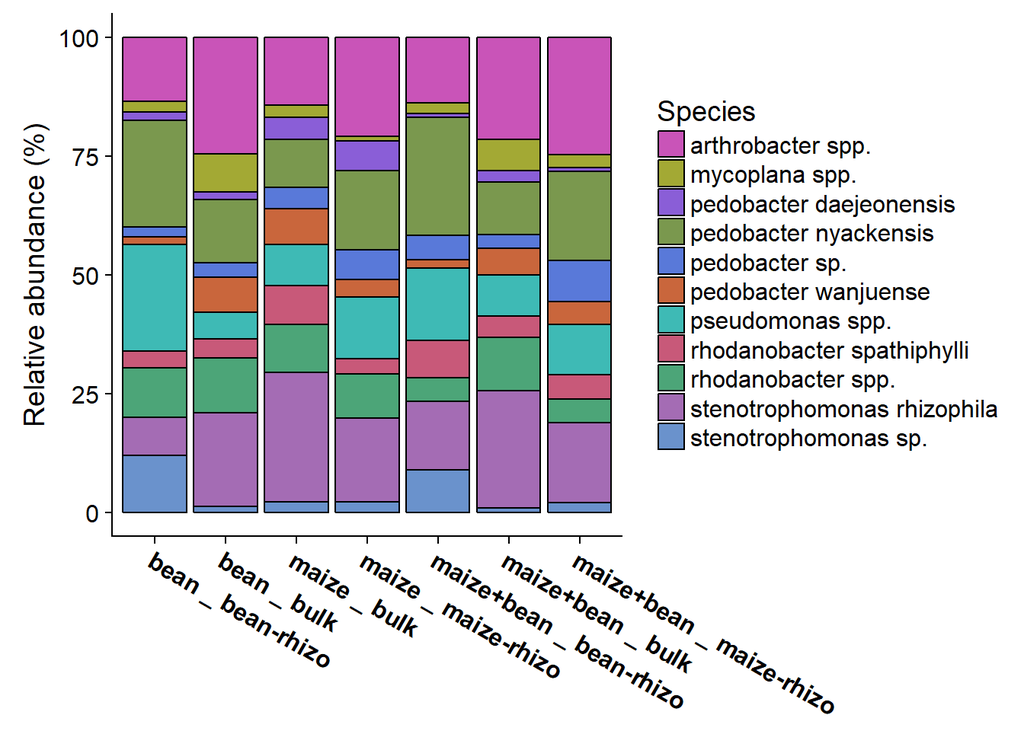

```r
physeq_sps_concom_highVar0.5_pct <-
  physeq_sps_concom_highVar0.5 %>%
  transform_sample_counts(function(OTU) OTU/sum(OTU)*100 )

physeq_sps_concom_highVar0.5_pct %>%
  plot_bar(fill = "Species",
         x = "concom")+
  theme(axis.text.x = element_text(angle = 330, size = 12, face = "bold"),
        axis.title.x = element_blank())+
  ylab(label = "Relative abundance (%)")+
  scale_fill_manual(values = c("#c954b8",
"#a3a934",
"#8a5ed7",
"#7a984e",
"#5979d9",
"#c9663c",
"#3ebab5",
"#c85979",
"#4ca578",
"#a46cb4",
"#6a92cc"))
```

Still no clear differences when comparing monoculture and polyculture rhizo-microbiome according to the corresponding bulk soil.

##### Var > 1

```r
#var > 1 : all is the same, beside we put the variance thershold up to 1
physeq_sps_concom_pct_highVar1 =
  filter_taxa(physeq_sps_concom_pct,
              function(x) var(x) > 1, TRUE)

physeq_sps_concom_pct_highVar1@tax_table
```

```
## Taxonomy Table:     [6 taxa by 7 taxonomic ranks]:
##          Domain     Phylum           Class
## OTU10587 "bacteria" "proteobacteria" "gammaproteobacteria"
## OTU10    "bacteria" "proteobacteria" "gammaproteobacteria"
## OTU7     "bacteria" "proteobacteria" "gammaproteobacteria"
## OTU1     "bacteria" "actinobacteria" "actinobacteria"
## OTU3     "bacteria" "proteobacteria" "gammaproteobacteria"
## OTU6     "bacteria" "bacteroidetes"  "sphingobacteriia"
##          Order                Family                Genus
## OTU10587 "xanthomonadales"    "xanthomonadaceae"    "stenotrophomonas"
## OTU10    "xanthomonadales"    "xanthomonadaceae"    "stenotrophomonas"
## OTU7     "xanthomonadales"    "xanthomonadaceae"    "rhodanobacter"
## OTU1     "actinomycetales"    "micrococcaceae"      "arthrobacter"
## OTU3     "pseudomonadales"    "pseudomonadaceae"    "pseudomonas"
## OTU6     "sphingobacteriales" "sphingobacteriaceae" "pedobacter"
##          Species
## OTU10587 "stenotrophomonas rhizophila"
## OTU10    "stenotrophomonas sp."
## OTU7     "rhodanobacter spp."
## OTU1     "arthrobacter spp."
## OTU3     "pseudomonas spp."
## OTU6     "pedobacter nyackensis"
```

```r
physeq_sps_concom_names_highVar1 <-
  as.data.frame(physeq_sps_concom_pct_highVar1@tax_table)

physeq_sps_concom_highVar1 <- subset_taxa(physeq_sps_concom, Species %in% physeq_sps_concom_names_highVar1$Species)

physeq_sps_concom_highVar1@tax_table
```

```
## Taxonomy Table:     [6 taxa by 7 taxonomic ranks]:
##          Domain     Phylum           Class
## OTU10587 "bacteria" "proteobacteria" "gammaproteobacteria"
## OTU10    "bacteria" "proteobacteria" "gammaproteobacteria"
## OTU7     "bacteria" "proteobacteria" "gammaproteobacteria"
## OTU1     "bacteria" "actinobacteria" "actinobacteria"
## OTU3     "bacteria" "proteobacteria" "gammaproteobacteria"
## OTU6     "bacteria" "bacteroidetes"  "sphingobacteriia"
##          Order                Family                Genus
## OTU10587 "xanthomonadales"    "xanthomonadaceae"    "stenotrophomonas"
## OTU10    "xanthomonadales"    "xanthomonadaceae"    "stenotrophomonas"
## OTU7     "xanthomonadales"    "xanthomonadaceae"    "rhodanobacter"
## OTU1     "actinomycetales"    "micrococcaceae"      "arthrobacter"
## OTU3     "pseudomonadales"    "pseudomonadaceae"    "pseudomonas"
## OTU6     "sphingobacteriales" "sphingobacteriaceae" "pedobacter"
##          Species
## OTU10587 "stenotrophomonas rhizophila"
## OTU10    "stenotrophomonas sp."
## OTU7     "rhodanobacter spp."
## OTU1     "arthrobacter spp."
## OTU3     "pseudomonas spp."
## OTU6     "pedobacter nyackensis"
```

```r
physeq_sps_concom_highVar1@otu_table
```

```
## OTU Table:          [6 taxa and 7 samples]
##                      taxa are columns
##                          OTU10587 OTU10  OTU7  OTU1  OTU3  OTU6
## bean _ bean-rhizo           10818 16130 14035 18021 30260 30162
## bean _ bulk                 26197  1810 15326 32599  7409 17630
## maize _ bulk                62862  5351 23319 32756 19871 23354
## maize _ maize-rhizo         43365  5446 23108 51022 31586 40844
## maize+bean _ bean-rhizo     38901 24610 13680 37471 41379 67471
## maize+bean _ bulk           71576  3038 32872 62441 25363 32331
## maize+bean _ maize-rhizo    40368  4968 12009 59141 25425 44628
```

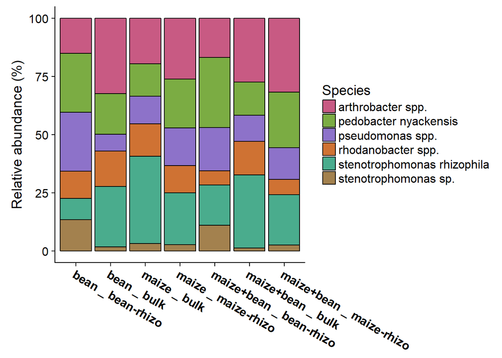

```r
physeq_sps_concom_highVar1_pct <-
  physeq_sps_concom_highVar1 %>%
  transform_sample_counts(function(OTU) OTU/sum(OTU)*100 )

physeq_sps_concom_highVar1_pct %>%
  plot_bar(fill = "Species",
         x = "concom")+
  theme(axis.text.x = element_text(angle = 330, size = 12, face = "bold"),
        axis.title.x = element_blank())+
  ylab(label = "Relative abundance (%)")+
  scale_fill_manual(values = c("#c85a83",
"#7bac43",
"#8d72c9",
"#cf7233",
"#4aac8d",
"#a3814e"))
```

Still no clear differences when comparing monoculture and polyculture rhizo-microbiome according to the corresponding bulk soil. It’s not easy to compare the taxonomical structure pattern between monoculture and polyculture rhizo-bulk microbiome. But when comparing rhizo-microbiome and the corresponding bulk soil microbiome we can’t observe clear shifts between the monoculture and the polyculture condition. Maybe working on a way to normalize rhizo-microbiome structure with the corresponding bulk soil structure could be a good idea to make visualisation easier.

## NMDS

A common way to represent microbiome composition proximity between samples is the Nonmetric Multidimensional scaling (NMDS). The NMDS algorithm uses a distance matrix (here Unifrac distance measure was used) to map the samples in a two-dimensional ordination space. Colours indicate the soil origin (farmers) and shapes indicate culture conditions. Bulk soil samples are displayed as filled shapes, monoculture bean rhizosphere as circular empty shapes, maize rhizosphere as triangular empty shapes, and polyculture bean and maize rhizosphere as squares respectively containing verticale-horizontal cross and diagonal cross.

```r
PSUF <- UniFrac(physeq)
PS.NMDS <- ordinate(physeq, "NMDS", PSUF)
```

```
## *** No convergence -- monoMDS stopping criteria:
##     20: stress ratio > sratmax
```

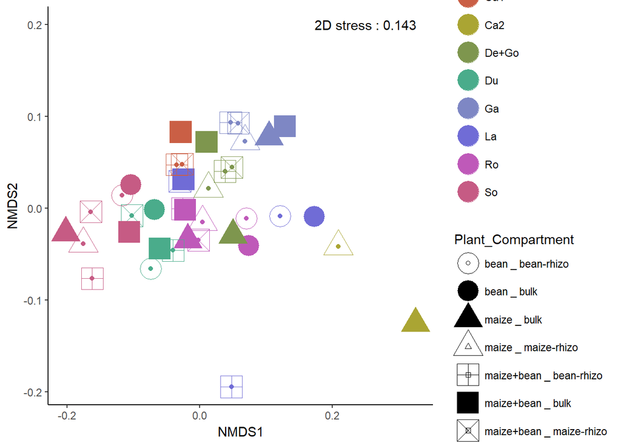

```r
plot_ordination(physeq, PS.NMDS, "samples", color="farmer2")+
  geom_point(aes(shape = concom),size=8)+
  scale_shape_manual(values = c(1,16,17,2,12,15,7))+
  scale_color_manual(values = c("#ca5f45",
"#aaa533",
"#7e964e",
"#4aac8b",
"#7e87c4",
"#706cd6",
"#bf59b9",
"#c65b84"))+
  theme_classic()+
  labs(shape = "Plant_Compartment", color = "Farmers")+
  annotate("text", x = 0.25, y = 0.2, label = "2D stress : 0.143")
```

It seems that there is not any pattern of polyculture effect. Distances between bulk soil and rhizosphere, as well as monoculture and polyculture microbiome, are different for every soil origin. But in the overall, samples can almost be differentiated on the farm origin.

## Coinertie

The coinertia analysis will provide the relationship between the soil parameters dataset and the OTU sequence counts dataset.Two separated pcas were run and coinertia find a couple of axes in each pca on which the samples are projected. ###Soil acp

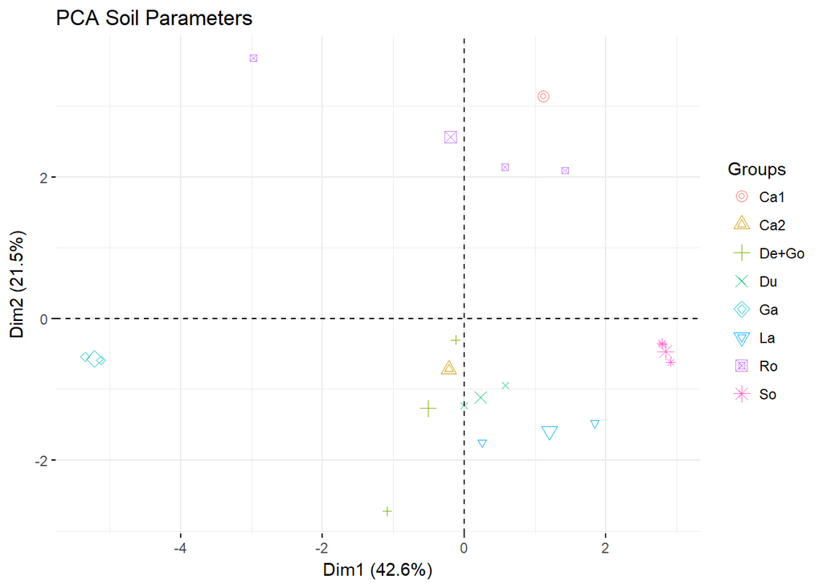

```r
sol <- meta_df1[,25:38]

sol <- as.data.frame(sol)
farmersol <- as.factor(meta_df1$farmer2)

pcasoil <- dudi.pca(sol, scan = F, nf = 4)


fviz_pca_ind(pcasoil,title="PCA Soil Parameters", label="none", habillage=meta_df1$farmer2)
```

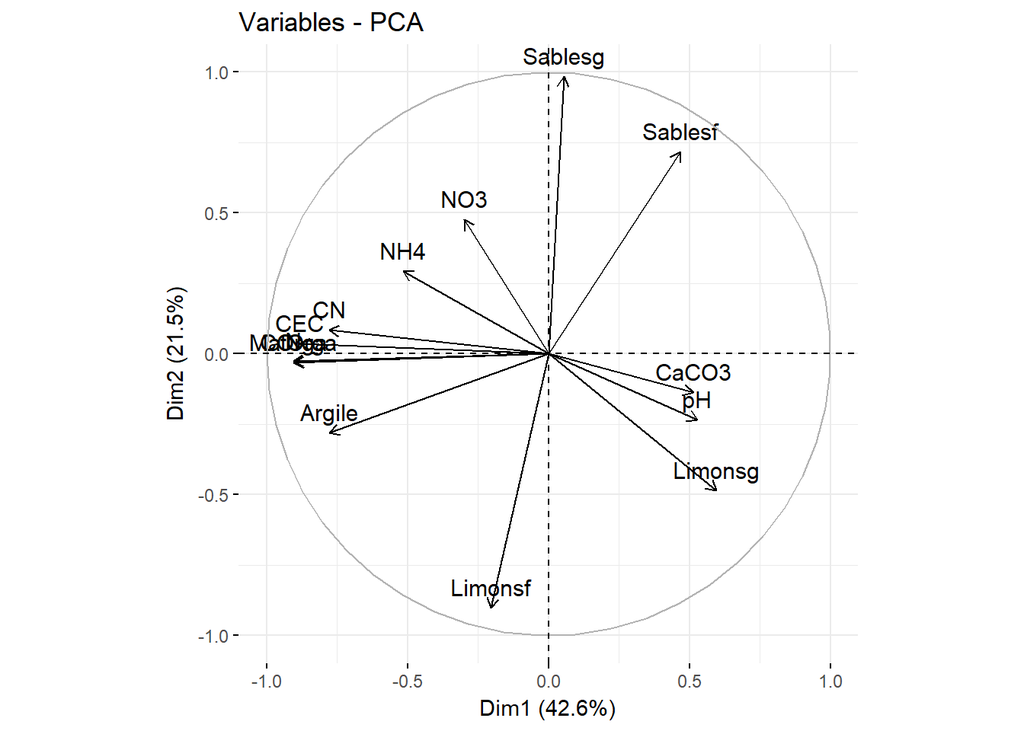

```r
fviz_pca_var(pcasoil)
```

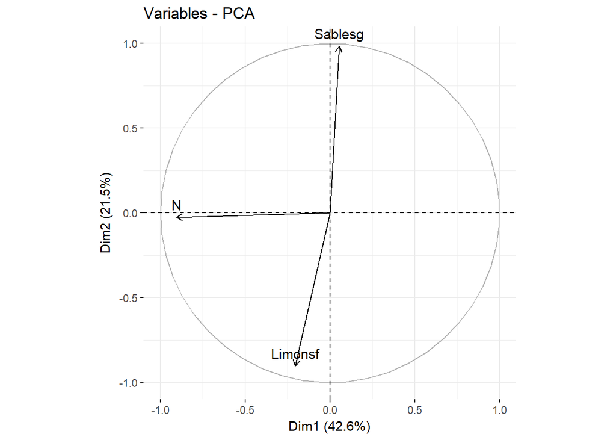

```r
fviz_pca_var(pcasoil, select.var = list(contrib = 3))
```

Here are the three soil parameters contributing the most to axe formation. So we can see that the most discriminant soil parameters are particle size (Coarse sands and fine silts) and nitrogen content (N).

### OTUs pca

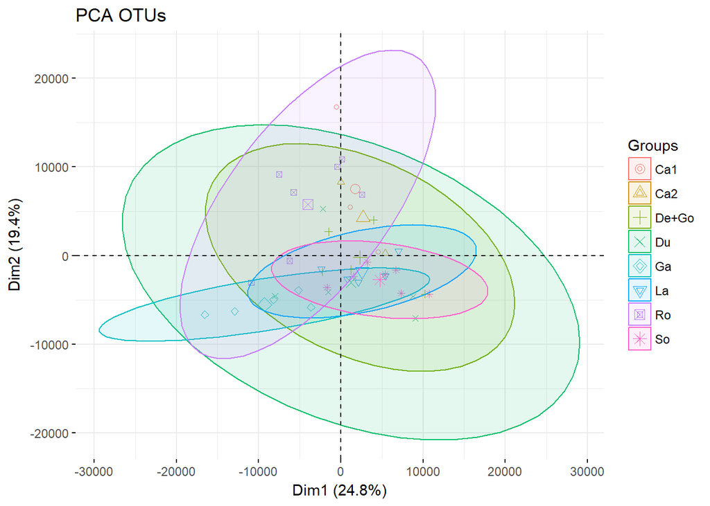

```r
pcaotus <- dudi.pca(otusmatt, scan = FALSE, scale = FALSE, nf = 3)

fviz_pca_ind(pcaotus,
             title="PCA OTUs",
             label="none",
             habillage = meta_df1$farmer2, addEllipses = TRUE)
```

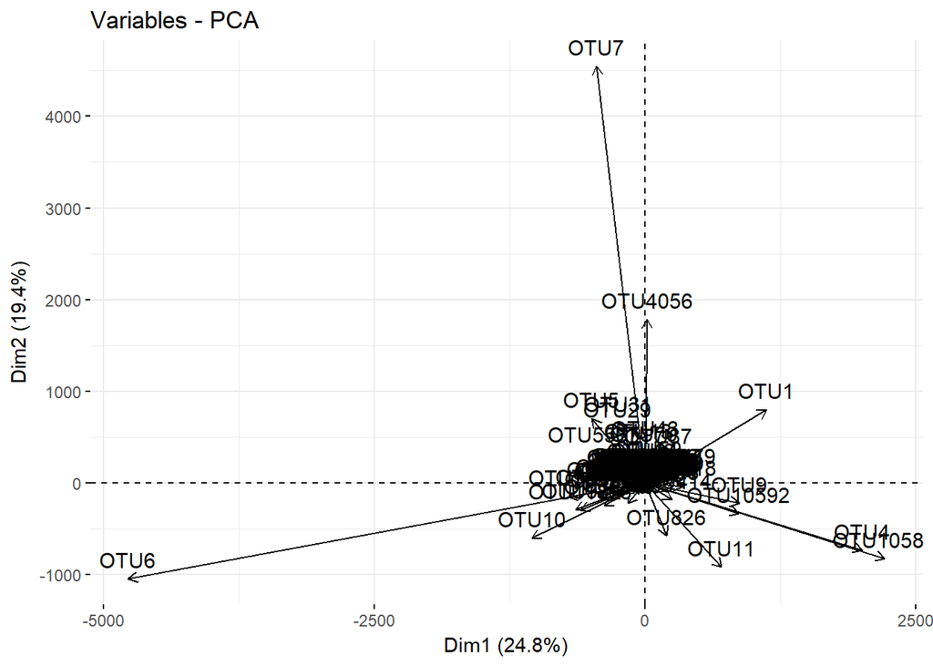

```r
fviz_pca_var(pcaotus)
```

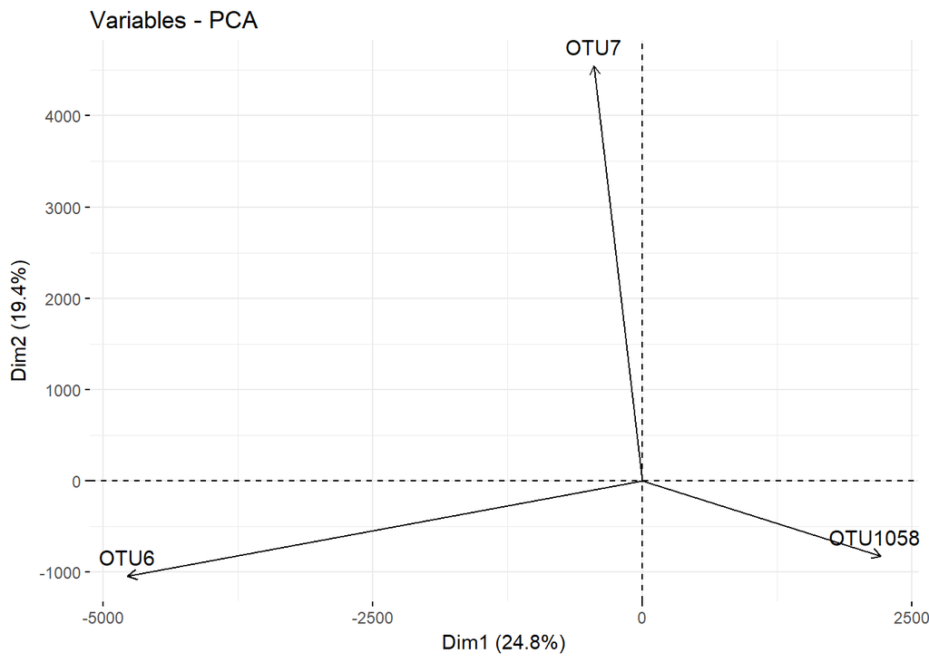

```r
fviz_pca_var(pcaotus, select.var = list(contrib = 3))
```

Here are the three OTUs (OTUs 6, 7, 1058) contributing the most to the 2 dimensions space formation.

### coinertia

Soil parameters-based projected samples are displayed in yellow. OTU sequences counts-based projected samples are displayed in blue. Coinertia strength can be estimated with a permutational test.

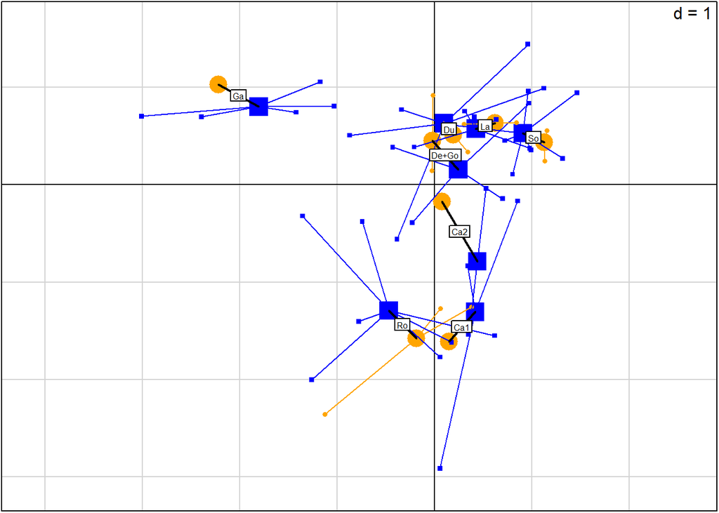

```r
coib <- coinertia(pcasoil, pcaotus, scannf = FALSE, nf = 2)

s.match.class(coib$mX, coib$mY, farmersol, col1 = rep("orange",
nlevels(farmersol)), col2 = rep("blue", nlevels(farmersol)),clabel = 0.5, cpoint = 0.6)
```

```r
perm3<-randtest(coib, nrepet = 10000)
perm3
```

```
## Monte-Carlo test
## Call: randtest.coinertia(xtest = coib, nrepet = 10000)
##
## Observation: 0.4504511
##
## Based on 10000 replicates
## Simulated p-value: 9.999e-05
## Alternative hypothesis: greater
##
##      Std.Obs  Expectation     Variance
## 9.8704277530 0.1393652013 0.0009933186
```

So here we can see that there is a strong relationship between the soil microbiome taxonomic structure and soil farm origin (underlying that soil parameters are different between farms).

## Venn

The Venn diagram calculates the number of OTUs shared and unshared between conditions. For this, only two sample sites were chosen, because they displayed maize and bean monocultures as well as polycultures.

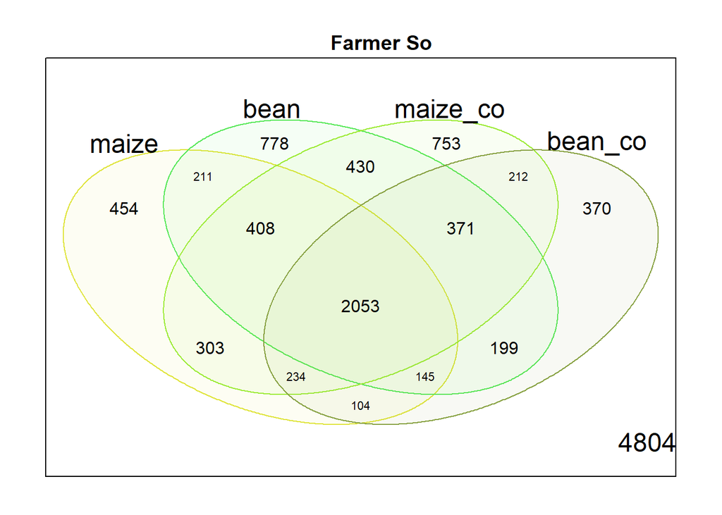

```
## integer(0)
```

```r
tabven <- cbind(otusmatt, sampledata)

tab_ma <- subset(tabven, concom =="maize _ maize-rhizo")
tab_ma_rou <- subset(tab_ma, farmer == "ROUX")
tab_ma_sol <- subset(tab_ma, farmer == "SOLLE")
tab_ma_f <- tab_ma[,1:11829]
tab_ma_rou_f <- tab_ma_rou[,1:11829]
tab_ma_sol_f <- tab_ma_sol[,1:11829]

tab_ha <- subset(tabven, concom == "bean _ bean-rhizo")
tab_ha_rou <- subset(tab_ha, farmer == "ROUX")
tab_ha_sol <- subset(tab_ha, farmer == "SOLLE")
tab_ha_f <- tab_ha[,1:11829]
tab_ha_rou_f <- tab_ha_rou[,1:11829]
tab_ha_sol_f <- tab_ha_sol[,1:11829]

tab_co <- subset(tabven, concom %in% c("maize+bean _ bean-rhizo", "maize+bean _ maize-rhizo"))
tab_co_ma <- subset(tab_co, compartment == "maize-rhizo")
tab_co_ha <- subset(tab_co, compartment == "bean-rhizo")
tab_co_ma_rou <- subset(tab_co_ma, farmer == "ROUX")
tab_co_ha_rou <- subset(tab_co_ha, farmer == "ROUX")
tab_co_ma_sol <- subset(tab_co_ma, farmer == "SOLLE")
tab_co_ha_sol <- subset(tab_co_ha, farmer == "SOLLE")

tab_co_f <- tab_co[,1:11829]
tab_co_ma_rou_f <- tab_co_ma_rou[,1:11829]
tab_co_ha_rou_f <- tab_co_ha_rou[,1:11829]
tab_co_ma_sol_f <- tab_co_ma_sol[,1:11829]
tab_co_ha_sol_f <- tab_co_ha_sol[,1:11829]

conditions1 <- data.frame(
  maize = colSums(tab_ma_sol_f),
  bean = colSums(tab_ha_sol_f),
  maize_co = colSums(tab_co_ma_sol_f),
  bean_co = colSums(tab_co_ha_sol_f))

conditions1[conditions1 > 0] <- 1

colvc1 <- c("#dfe43b","#58e859","#9deb37","#87a141")

vc1 <- vennCounts(conditions1)
vennDiagram(vc1, circle.col = colvc1)+
  title(main = "Farmer So")
```

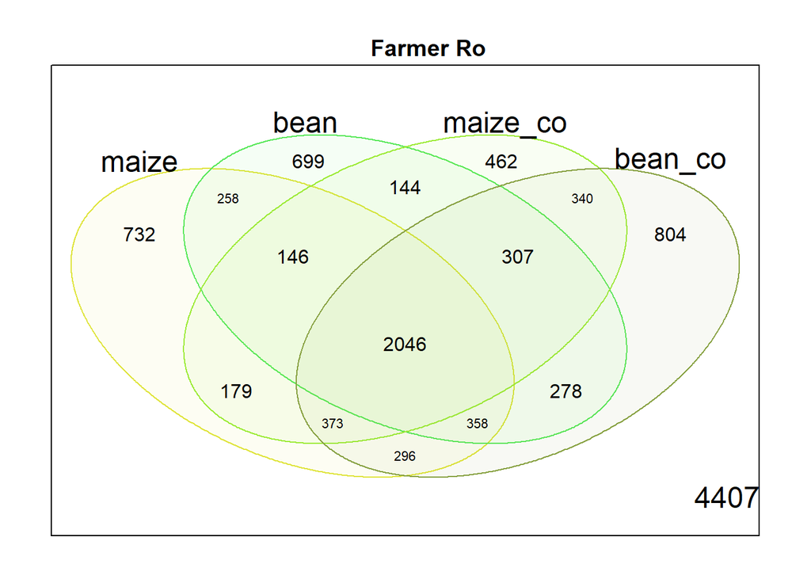

```
## integer(0)
```

```r
conditions2 <- data.frame(
  maize = colSums(tab_ma_rou_f),
  bean = colSums(tab_ha_rou_f),
  maize_co = colSums(tab_co_ma_rou_f),
  bean_co = colSums(tab_co_ha_rou_f))

conditions2[conditions2 > 0] <- 1

colvc2 <- c("#dfe43b","#58e859","#9deb37","#87a141")

vc2 <- vennCounts(conditions2)
vennDiagram(vc2, circle.col = colvc2)+
  title(main = "Farmer Ro")
```

First, we looked at the “farmer So” samples, where bean shows a lot (778) of unshared OTUs compared to the maize (454). Not much is shared only between maize and bean monoculture (211) as well as polyculture (212) condition. Bean monoculture condition shares less OTUs with bean coculture (199) than maize monoculture and polyculture (303). In total, bean and maize monoculture shared 2817 OTUs (211+408+2053+145). Bean and maize polyculture shared 2870 OTUs (212+371+2053+234). Therefore, maize and bean rhizosphere don’t share more OTUs when they are grown together. But interestingly, unlike the monoculture condition, the maize coculture-condition rhizosphere showed a higher number of unshared OTUs (753) compared to bean rhizosphere (370).

[output not shown]

## DESeq2

DESeq2 is a bioconductor package for R software, providing a method for differential analysis of count data. Basically, the null hypothesis that the logarithmic fold change between treatments for OTU sequence counts is exactly zero. generated p-values are then adjusted with a False Discovery Rate method (method of Benjamini, Hochberg and Yekutieli).

### maize_maize-rhizo vs maize+brean_maize-rhizo padj

Here we tested the coculture treatment effect on the maize rhizo-microbiome against the monoculture controle. To increase the test power, we reduced the FDR correction stringency by filtering OTUs rarely counted within the dataset. Here, 5 samples of each treatment and control are available (i.e. a total of 10 samples). We chose to remove OTUs cumulating less than 15 sequences within the 10 samples and absent from more than 6 samples.

```r
mamomaco <- subset_samples(physeq, concom %in% c("maize _ maize-rhizo", "maize+bean _ maize-rhizo"))
mamomaco <- subset_samples(mamomaco, farmer3 %in% c("Ro", "Ga", "So", "Ca", "De+Go"))

meta_data_mamomaco <- mamomaco@sam_data
meta_data_mamomaco <- meta_data_mamomaco[,"condition"]
colnames(meta_data_mamomaco) <- c("culture")
meta_data_mamomaco <- as.data.frame(meta_data_mamomaco)

tax <- as.data.frame(mamomaco@tax_table)
```

### Phylum level

According to the exploratory analysis ran above and the PERMANOVA, ran bellow, we do not expect to detect any significative OTU sequence-count changes at the “Phylum” taxonomic level. But it costs nothing to give it a try.

```r
mamomaco_plm <- tax_glom(mamomaco, taxrank = "Phylum")

maize_plm <- as.data.frame (mamomaco_plm@otu_table)

maize_plm_sup15 <- maize_plm[rowSums(maize_plm) > 15,]

maize_plm_sup15_max6 <- maize_plm_sup15[rowSums(maize_plm_sup15 ==0) <= 6,]

tax_mamomaco_plm_sup15_max6 <- subset(tax, rownames(tax) %in% rownames(maize_plm_sup15_max6))

mmvsmc_plm_s15m6 <- DESeqDataSetFromMatrix(maize_plm_sup15_max6,
                                 meta_data_mamomaco,
                                 design = ~ culture)
mmvsmc_plm_s15m6 <- DESeq(mmvsmc_plm_s15m6)

mmvsmc_plm_s15m6_res <- results(mmvsmc_plm_s15m6, cooksCutoff = FALSE)

alpha = 0.05

plm_maize_s15m6_sigtab = mmvsmc_plm_s15m6_res[which(mmvsmc_plm_s15m6_res$padj <= alpha), ]

plm_maize_s15m6_sigtab
```

```
## log2 fold change (MLE): culture maize.bean vs maize
## Wald test p-value: culture maize.bean vs maize
## DataFrame with 0 rows and 6 columns
```

##### High variance

As it has been done for visualisation analysis, we can also try to increase the test power by filtering low variance OTUs.

```r
mamomaco_plm_highVar0.5 =
  filter_taxa(mamomaco_plm,
              function(x) var(x) > 0.5, TRUE)

maize_plm_highVar0.5 <- as.data.frame (mamomaco_plm_highVar0.5@otu_table)

maize_plm_highVar0.5_sup15 <- maize_plm_highVar0.5[rowSums(maize_plm_highVar0.5) > 15,]

maize_plm_highVar0.5_sup15_max6 <- maize_plm_highVar0.5_sup15[rowSums(maize_plm_highVar0.5_sup15 ==0) <= 6,]

tax_maize_plm_highVar0.5_sup15_max6 <- subset(tax, rownames(tax) %in% rownames(maize_plm_highVar0.5_sup15_max6))

mmvsmc_hv_plm_s15m6 <- DESeqDataSetFromMatrix(maize_plm_highVar0.5_sup15_max6,
                                 meta_data_mamomaco,
                                 design = ~ culture)
mmvsmc_hv_plm_s15m6 <- DESeq(mmvsmc_hv_plm_s15m6)

mmvsmc_hv_plm_s15m6_res <- results(mmvsmc_hv_plm_s15m6, cooksCutoff = FALSE)

alpha = 0.05

plm_maize_hv_s15m6_sigtab = mmvsmc_hv_plm_s15m6_res[which(mmvsmc_hv_plm_s15m6_res$padj <= alpha), ]

plm_maize_hv_s15m6_sigtab
```

```
## log2 fold change (MLE): culture maize.bean vs maize
## Wald test p-value: culture maize.bean vs maize
## DataFrame with 0 rows and 6 columns
```

### Class level

```r
mamomaco_cls <- tax_glom(mamomaco, taxrank = "Class")

maize_cls <- as.data.frame (mamomaco_cls@otu_table)

maize_cls_sup15 <- maize_cls[rowSums(maize_cls) > 15,]

maize_cls_sup15_max6 <- maize_cls_sup15[rowSums(maize_cls_sup15 ==0) <= 6,]

tax_mamomaco_cls_sup15_max6 <- subset(tax, rownames(tax) %in% rownames(maize_cls_sup15_max6))

mmvsmc_cls_s15m6 <- DESeqDataSetFromMatrix(maize_cls_sup15_max6,
                                 meta_data_mamomaco,
                                 design = ~ culture)
mmvsmc_cls_s15m6 <- DESeq(mmvsmc_cls_s15m6)

mmvsmc_cls_s15m6_res <- results(mmvsmc_cls_s15m6, cooksCutoff = FALSE)

alpha = 0.05

cls_maize_s15m6_sigtab = mmvsmc_cls_s15m6_res[which(mmvsmc_cls_s15m6_res$padj <= alpha), ]

cls_maize_s15m6_sigtab
```

```
## log2 fold change (MLE): culture maize.bean vs maize
## Wald test p-value: culture maize.bean vs maize
## DataFrame with 0 rows and 6 columns
```

##### High variance

```r
mamomaco_cls_highVar0.5 =
  filter_taxa(mamomaco_cls,
              function(x) var(x) > 0.5, TRUE)

maize_cls_highVar0.5 <- as.data.frame (mamomaco_cls_highVar0.5@otu_table)

maize_cls_highVar0.5_sup15 <- maize_cls_highVar0.5[rowSums(maize_cls_highVar0.5) > 15,]

maize_cls_highVar0.5_sup15_max6 <- maize_cls_highVar0.5_sup15[rowSums(maize_cls_highVar0.5_sup15 ==0) <= 6,]

tax_maize_cls_highVar0.5_sup15_max6 <- subset(tax, rownames(tax) %in% rownames(maize_cls_highVar0.5_sup15_max6))

mmvsmc_hv_cls_s15m6 <- DESeqDataSetFromMatrix(maize_cls_highVar0.5_sup15_max6,
                                 meta_data_mamomaco,
                                 design = ~ culture)
mmvsmc_hv_cls_s15m6 <- DESeq(mmvsmc_hv_cls_s15m6)

mmvsmc_hv_cls_s15m6_res <- results(mmvsmc_hv_cls_s15m6, cooksCutoff = FALSE)

alpha = 0.05

cls_maize_hv_s15m6_sigtab = mmvsmc_hv_cls_s15m6_res[which(mmvsmc_hv_cls_s15m6_res$padj <= alpha), ]

cls_maize_hv_s15m6_sigtab
```

```
## log2 fold change (MLE): culture maize.bean vs maize
## Wald test p-value: culture maize.bean vs maize
## DataFrame with 0 rows and 6 columns
```

### Order level

```r
mamomaco_odr <- tax_glom(mamomaco, taxrank = "Order")

maize_odr <- as.data.frame (mamomaco_odr@otu_table)

maize_odr_sup15 <- maize_odr[rowSums(maize_odr) > 15,]

maize_odr_sup15_max6 <- maize_odr_sup15[rowSums(maize_odr_sup15 ==0) <= 6,]

tax_mamomaco_odr_sup15_max6 <- subset(tax, rownames(tax) %in% rownames(maize_odr_sup15_max6))

mmvsmc_odr_s15m6 <- DESeqDataSetFromMatrix(maize_odr_sup15_max6,
                                 meta_data_mamomaco,
                                 design = ~ culture)
mmvsmc_odr_s15m6 <- DESeq(mmvsmc_odr_s15m6)

mmvsmc_odr_s15m6_res <- results(mmvsmc_odr_s15m6, cooksCutoff = FALSE)

alpha = 0.05

odr_maize_s15m6_sigtab = mmvsmc_odr_s15m6_res[which(mmvsmc_odr_s15m6_res$padj <= alpha), ]

odr_maize_s15m6_sigtab
```

```
## log2 fold change (MLE): culture maize.bean vs maize
## Wald test p-value: culture maize.bean vs maize
## DataFrame with 0 rows and 6 columns
```

##### High variance

```r
mamomaco_odr_highVar0.5 =
  filter_taxa(mamomaco_odr,
              function(x) var(x) > 0.5, TRUE)

maize_odr_highVar0.5 <- as.data.frame (mamomaco_odr_highVar0.5@otu_table)

maize_odr_highVar0.5_sup15 <- maize_odr_highVar0.5[rowSums(maize_odr_highVar0.5) > 15,]

maize_odr_highVar0.5_sup15_max6 <- maize_odr_highVar0.5_sup15[rowSums(maize_odr_highVar0.5_sup15 ==0) <= 6,]

tax_maize_odr_highVar0.5_sup15_max6 <- subset(tax, rownames(tax) %in% rownames(maize_odr_highVar0.5_sup15_max6))

mmvsmc_hv_odr_s15m6 <- DESeqDataSetFromMatrix(maize_odr_highVar0.5_sup15_max6,
                                 meta_data_mamomaco,
                                 design = ~ culture)
mmvsmc_hv_odr_s15m6 <- DESeq(mmvsmc_hv_odr_s15m6)

mmvsmc_hv_odr_s15m6_res <- results(mmvsmc_hv_odr_s15m6, cooksCutoff = FALSE)

alpha = 0.05

odr_maize_hv_s15m6_sigtab = mmvsmc_hv_odr_s15m6_res[which(mmvsmc_hv_odr_s15m6_res$padj <= alpha), ]

odr_maize_hv_s15m6_sigtab
```

```
## log2 fold change (MLE): culture maize.bean vs maize
## Wald test p-value: culture maize.bean vs maize
## DataFrame with 0 rows and 6 columns
```

### Family level

```r
mamomaco_fmy <- tax_glom(mamomaco, taxrank = "Family")

maize_fmy <- as.data.frame (mamomaco_fmy@otu_table)

maize_fmy_sup15 <- maize_fmy[rowSums(maize_fmy) > 15,]

maize_fmy_sup15_max6 <- maize_fmy_sup15[rowSums(maize_fmy_sup15 ==0) <= 6,]

tax_mamomaco_fmy_sup15_max6 <- subset(tax, rownames(tax) %in% rownames(maize_fmy_sup15_max6))

mmvsmc_fmy_s15m6 <- DESeqDataSetFromMatrix(maize_fmy_sup15_max6,
                                 meta_data_mamomaco,
                                 design = ~ culture)
mmvsmc_fmy_s15m6 <- DESeq(mmvsmc_fmy_s15m6)

mmvsmc_fmy_s15m6_res <- results(mmvsmc_fmy_s15m6, cooksCutoff = FALSE)

alpha = 0.05

fmy_maize_s15m6_sigtab = mmvsmc_fmy_s15m6_res[which(mmvsmc_fmy_s15m6_res$padj <= alpha), ]

fmy_maize_s15m6_sigtab
```

```
## log2 fold change (MLE): culture maize.bean vs maize
## Wald test p-value: culture maize.bean vs maize
## DataFrame with 1 row and 6 columns
##         baseMean log2FoldChange     lfcSE      stat       pvalue
##        <numeric>      <numeric> <numeric> <numeric>    <numeric>
## OTU198  65.09847       5.147514  1.377443  3.737008 0.0001862229
##              padj
##         <numeric>
## OTU198 0.03705835
```

```r
#Up

fmy_maize_s15m6_sigtab_up <- fmy_maize_s15m6_sigtab[which(fmy_maize_s15m6_sigtab@listData$log2FoldChange > 0),]

cbind(head(fmy_maize_s15m6_sigtab_up[order(fmy_maize_s15m6_sigtab_up$padj),]), tax[row.names(head(fmy_maize_s15m6_sigtab_up[order(fmy_maize_s15m6_sigtab_up$padj),])),2:7])
```

```
## DataFrame with 1 row and 12 columns
##         baseMean log2FoldChange     lfcSE      stat       pvalue
##        <numeric>      <numeric> <numeric> <numeric>    <numeric>
## OTU198  65.09847       5.147514  1.377443  3.737008 0.0001862229
##              padj         Phylum               Class         Order
##         <numeric>       <factor>            <factor>      <factor>
## OTU198 0.03705835 proteobacteria alphaproteobacteria rickettsiales
##                Family    Genus                Species
##              <factor> <factor>               <factor>
## OTU198 rickettsiaceae orientia orientia tsutsugamushi
```

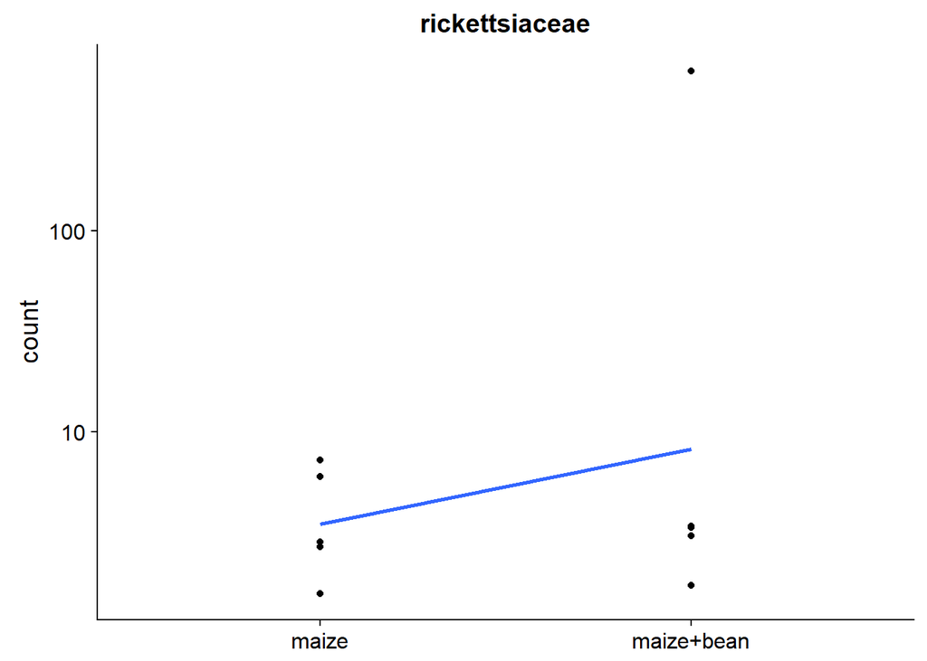

```r
plots.list <- lapply(row.names(head(fmy_maize_s15m6_sigtab_up[order(fmy_maize_s15m6_sigtab_up$padj),])),
                     function(x) {
                       d <- plotCounts(mmvsmc_fmy_s15m6, x, intgroup=c("culture"), returnData=TRUE)
                       ggplot(d, aes(x=culture, y=count, group=1)) +
                         geom_point() + stat_smooth(se=FALSE,method="loess") + scale_y_log10() +
                         ggtitle(tax[x,"Family"]) +
                         theme(axis.title.x = element_blank(), legend.title=element_blank(), legend.position="top", legend.box="horizontal", legend.key.height = unit(.5, "cm"),legend.text=element_text(size=6))
                     }
)
do.call(grid.arrange,plots.list)
```

Since we do not have any method for normalizing OTU sequence-count from treatment according to the corresponding bulk soil, it’s necessary to check if there is a similar number of sequences of the considered OTU between bulk soil and treatment.

```r
ma_fa <- tax_glom(physeq, taxrank = "Family")
ma_fa <- subset_samples(ma_fa, condition != "bean")
ma_fa <- subset_samples(ma_fa, compartment != "bean-rhizo")
ma_fa_concom <- merge_samples(ma_fa, "concom")
ma_fa_concom@sam_data$concom = c("maize _ bulk", "maize _ maize-rhizo", "maize+bean _ bulk", "maize+bean _ maize-rhizo")

ma_fa_concom_ric <- subset_taxa(ma_fa_concom,Family =="rickettsiaceae")
```

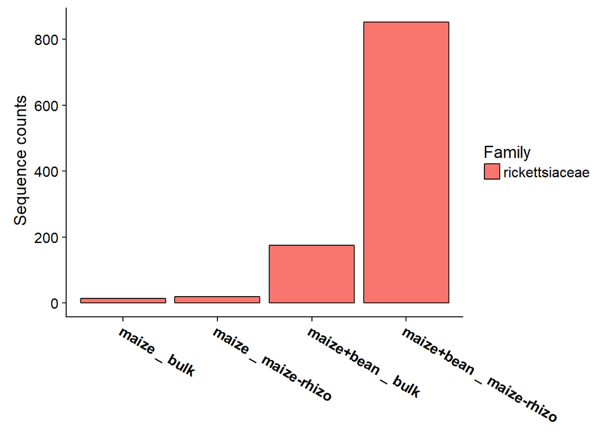

```r
ma_fa_concom_ric %>%
  plot_bar(fill = "Family",
         x = "concom")+
  theme(axis.text.x = element_text(angle = 330, size = 12, face = "bold"),
        axis.title.x = element_blank())+
  ylab(label = " Sequence counts")
```

The monoculture samples display a very low number of *Rickettsiaceae* family sequences, either within the bulk soil and in maize rhizosphere. There is a big difference between monoculture and polyculture bulk soils in term of Rickettsiaceae sequence abundance. So it’s hard to determine if the *Rickettsiaceae* family is more abundant in polyculture maize rhizosphere than in monoculture because of the treatment or because of the soil physicochemical proprieties.

We can check what happens for the mono and polyculture bean treatments.

```r
be_fa <- tax_glom(physeq, taxrank = "Family")
be_fa <- subset_samples(be_fa, condition != "maize")
be_fa <- subset_samples(be_fa, compartment != "maize-rhizo")
be_fa_concom <- merge_samples(be_fa, "concom")
be_fa_concom@sam_data$concom = c("bean _ bean-rhizo", "bean _ bulk", "maize+bean _ bean-rhizo", "maize+bean _ bulk")

be_fa_concom_ric <- subset_taxa(be_fa_concom,Family =="rickettsiaceae")
```

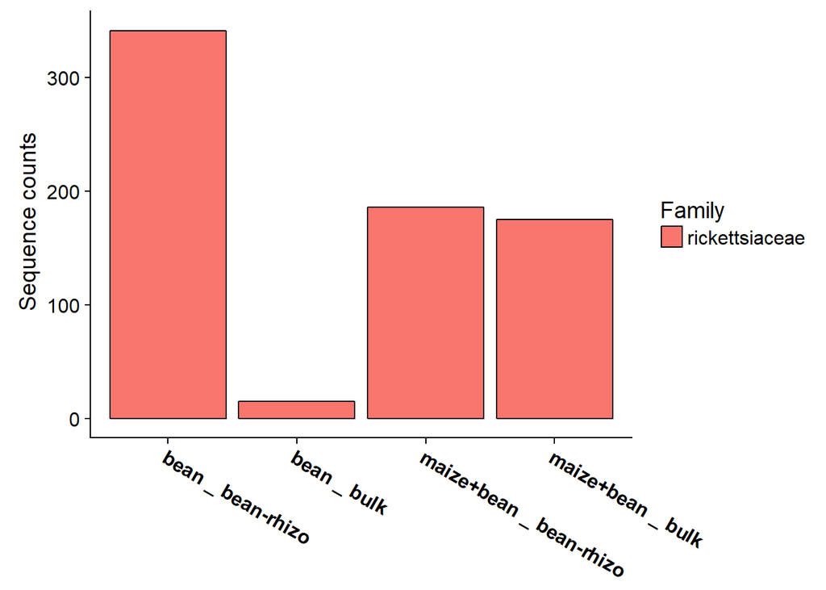

```r
be_fa_concom_ric %>%
  plot_bar(fill = "Family",
         x = "concom")+
  theme(axis.text.x = element_text(angle = 330, size = 12, face = "bold"),
        axis.title.x = element_blank())+
  ylab(label = " Sequence counts")
```

It’s interesting that even with a really low *Rickettsiaceae* abundance in the monoculture bulk soil, this abundance is fairly high in the monoculture-bean rhizosphere. Also, the abundance in the rhizosphere samples is lower for the polyculture treatment, while the polyculture bulk soil shows a higher abundance that the monoculture one.

##### High variance

```r
mamomaco_fmy_highVar0.5 =
  filter_taxa(mamomaco_fmy,
              function(x) var(x) > 0.5, TRUE)

maize_fmy_highVar0.5 <- as.data.frame (mamomaco_fmy_highVar0.5@otu_table)

maize_fmy_highVar0.5_sup15 <- maize_fmy_highVar0.5[rowSums(maize_fmy_highVar0.5) > 15,]

maize_fmy_highVar0.5_sup15_max6 <- maize_fmy_highVar0.5_sup15[rowSums(maize_fmy_highVar0.5_sup15 ==0) <= 6,]

tax_maize_fmy_highVar0.5_sup15_max6 <- subset(tax, rownames(tax) %in% rownames(maize_fmy_highVar0.5_sup15_max6))

mmvsmc_hv_fmy_s15m6 <- DESeqDataSetFromMatrix(maize_fmy_highVar0.5_sup15_max6,
                                 meta_data_mamomaco,
                                 design = ~ culture)
mmvsmc_hv_fmy_s15m6 <- DESeq(mmvsmc_hv_fmy_s15m6)

mmvsmc_hv_fmy_s15m6_res <- results(mmvsmc_hv_fmy_s15m6, cooksCutoff = FALSE)

alpha = 0.05

fmy_maize_hv_s15m6_sigtab = mmvsmc_hv_fmy_s15m6_res[which(mmvsmc_hv_fmy_s15m6_res$padj <= alpha), ]

fmy_maize_hv_s15m6_sigtab
```

```
## log2 fold change (MLE): culture maize.bean vs maize
## Wald test p-value: culture maize.bean vs maize
## DataFrame with 1 row and 6 columns
##         baseMean log2FoldChange     lfcSE      stat       pvalue
##        <numeric>      <numeric> <numeric> <numeric>    <numeric>
## OTU198  65.09847       5.147514  1.377443  3.737008 0.0001862229
##              padj
##         <numeric>
## OTU198 0.03705835
```

```r
fmy_maize_hv_s15m6_sigtab_up <- fmy_maize_hv_s15m6_sigtab[which(fmy_maize_hv_s15m6_sigtab@listData$log2FoldChange > 0),]

cbind(head(fmy_maize_hv_s15m6_sigtab_up[order(fmy_maize_hv_s15m6_sigtab_up$padj),]), tax_maize_fmy_highVar0.5_sup15_max6[row.names(head(fmy_maize_hv_s15m6_sigtab_up[order(fmy_maize_hv_s15m6_sigtab_up$padj),])),2:7])
```

```
## DataFrame with 1 row and 12 columns
##         baseMean log2FoldChange     lfcSE      stat       pvalue
##        <numeric>      <numeric> <numeric> <numeric>    <numeric>
## OTU198  65.09847       5.147514  1.377443  3.737008 0.0001862229
##              padj         Phylum               Class         Order
##         <numeric>       <factor>            <factor>      <factor>
## OTU198 0.03705835 proteobacteria alphaproteobacteria rickettsiales
##                Family    Genus                Species
##              <factor> <factor>               <factor>
## OTU198 rickettsiaceae orientia orientia tsutsugamushi
```

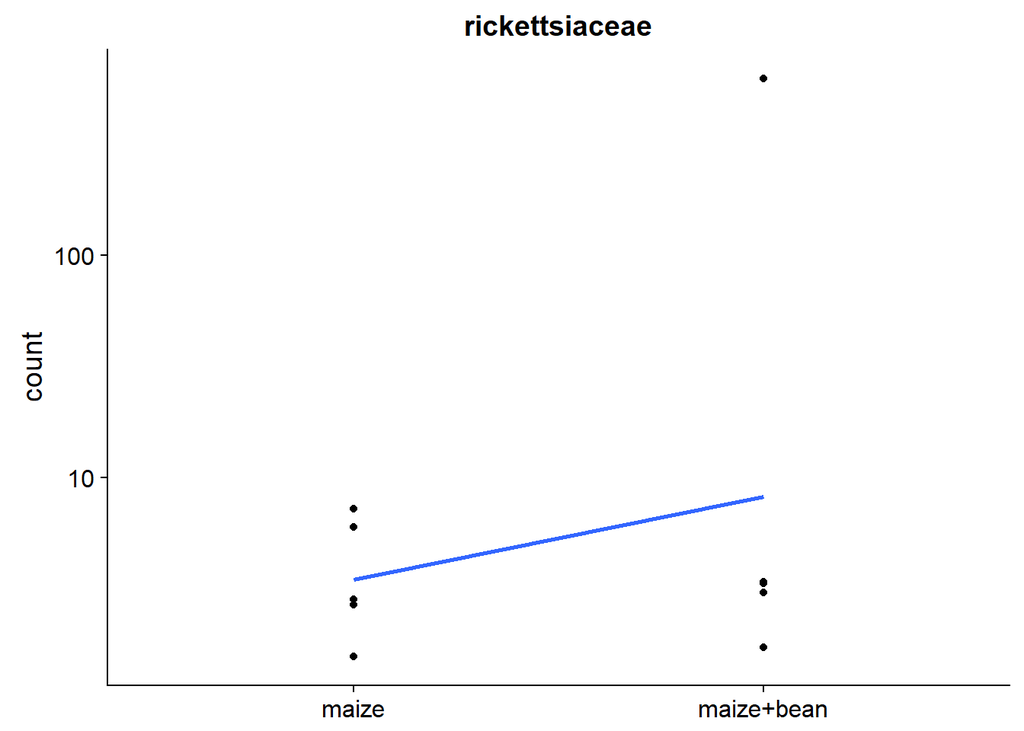

```r
plots.list <- lapply(row.names(head(fmy_maize_hv_s15m6_sigtab_up[order(fmy_maize_hv_s15m6_sigtab_up$padj),])),
                     function(x) {
                       d <- plotCounts(mmvsmc_hv_fmy_s15m6, x, intgroup=c("culture"), returnData=TRUE)
                       ggplot(d, aes(x=culture, y=count, group=1)) +
                         geom_point() + stat_smooth(se=FALSE,method="loess") + scale_y_log10() +
                         ggtitle(tax[x,"Family"]) +
                         theme(axis.title.x = element_blank(), legend.title=element_blank(), legend.position="top", legend.box="horizontal", legend.key.height = unit(.5, "cm"),legend.text=element_text(size=6))
                     }
)
do.call(grid.arrange,plots.list)
```

Same result than without filter.

### Genus level

```r
mamomaco_gns <- tax_glom(mamomaco, taxrank = "Genus")

maize_gns <- as.data.frame (mamomaco_gns@otu_table)

maize_gns_sup15 <- maize_gns[rowSums(maize_gns) > 15,]

maize_gns_sup15_max6 <- maize_gns_sup15[rowSums(maize_gns_sup15 ==0) <= 6,]

tax_mamomaco_gns_sup15_max6 <- subset(tax, rownames(tax) %in% rownames(maize_gns_sup15_max6))

mmvsmc_gns_s15m6 <- DESeqDataSetFromMatrix(maize_gns_sup15_max6,
                                 meta_data_mamomaco,
                                 design = ~ culture)
mmvsmc_gns_s15m6 <- DESeq(mmvsmc_gns_s15m6)

mmvsmc_gns_s15m6_res <- results(mmvsmc_gns_s15m6, cooksCutoff = FALSE)

alpha = 0.05

gns_maize_s15m6_sigtab = mmvsmc_gns_s15m6_res[which(mmvsmc_gns_s15m6_res$padj <= alpha), ]

gns_maize_s15m6_sigtab
```

```
## log2 fold change (MLE): culture maize.bean vs maize
## Wald test p-value: culture maize.bean vs maize
## DataFrame with 1 row and 6 columns
##         baseMean log2FoldChange     lfcSE      stat       pvalue
##        <numeric>      <numeric> <numeric> <numeric>    <numeric>
## OTU198   64.1854       6.308936  1.598371  3.947104 7.910234e-05
##              padj
##         <numeric>
## OTU198 0.04089591
```

```r
#Up

gns_maize_s15m6_sigtab_up <- gns_maize_s15m6_sigtab[which(gns_maize_s15m6_sigtab@listData$log2FoldChange > 0),]

cbind(head(gns_maize_s15m6_sigtab_up[order(gns_maize_s15m6_sigtab_up$padj),]), tax[row.names(head(gns_maize_s15m6_sigtab_up[order(gns_maize_s15m6_sigtab_up$padj),])),2:7])
```

```
## DataFrame with 1 row and 12 columns
##         baseMean log2FoldChange     lfcSE      stat       pvalue
##        <numeric>      <numeric> <numeric> <numeric>    <numeric>
## OTU198   64.1854       6.308936  1.598371  3.947104 7.910234e-05
##              padj         Phylum               Class         Order
##         <numeric>       <factor>            <factor>      <factor>
## OTU198 0.04089591 proteobacteria alphaproteobacteria rickettsiales
##                Family    Genus                Species
##              <factor> <factor>               <factor>
## OTU198 rickettsiaceae orientia orientia tsutsugamushi
```

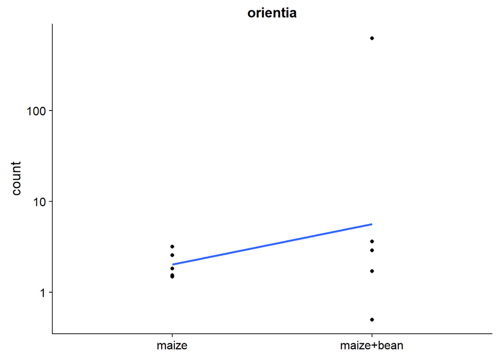

```r
plots.list <- lapply(row.names(head(gns_maize_s15m6_sigtab_up[order(gns_maize_s15m6_sigtab_up$padj),])),
                     function(x) {
                       d <- plotCounts(mmvsmc_gns_s15m6, x, intgroup=c("culture"), returnData=TRUE)
                       ggplot(d, aes(x=culture, y=count, group=1)) +
                         geom_point() + stat_smooth(se=FALSE,method="loess") + scale_y_log10() +
                         ggtitle(tax[x,"Genus"]) +
                         theme(axis.title.x = element_blank(), legend.title=element_blank(), legend.position="top", legend.box="horizontal", legend.key.height = unit(.5, "cm"),legend.text=element_text(size=6))
                     }
)
do.call(grid.arrange,plots.list)
```

So this is probably the Rickettsia family member which is responsible for the biggest part of the result observed above.

```r
ma_ge <- tax_glom(physeq, taxrank = "Genus")
ma_ge <- subset_samples(ma_ge, condition != "bean")
ma_ge <- subset_samples(ma_ge, compartment != "bean-rhizo")
ma_ge_concom <- merge_samples(ma_ge, "concom")
ma_ge_concom@sam_data$concom = c("maize _ bulk", "maize _ maize-rhizo", "maize+bean _ bulk", "maize+bean _ maize-rhizo")

ma_ge_concom_ric <- subset_taxa(ma_ge_concom,Genus =="orientia")
```

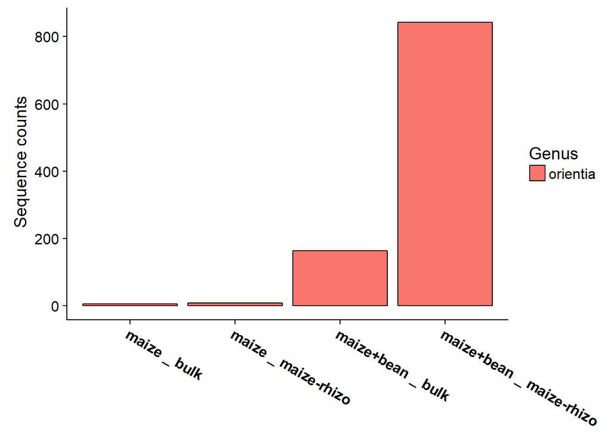

```r
ma_ge_concom_ric %>%
  plot_bar(fill = "Genus",
         x = "concom")+
  theme(axis.text.x = element_text(angle = 330, size = 12, face = "bold"),
        axis.title.x = element_blank())+
  ylab(label = " Sequence counts")
```

```r
be_ge <- tax_glom(physeq, taxrank = "Genus")
be_ge <- subset_samples(be_ge, condition != "maize")
be_ge <- subset_samples(be_ge, compartment != "maize-rhizo")
be_ge_concom <- merge_samples(be_ge, "concom")
be_ge_concom@sam_data$concom = c("bean _ bean-rhizo", "bean _ bulk", "maize+bean _ bean-rhizo", "maize+bean _ bulk")

be_ge_concom_ric <- subset_taxa(be_ge_concom,Genus =="orientia")
```

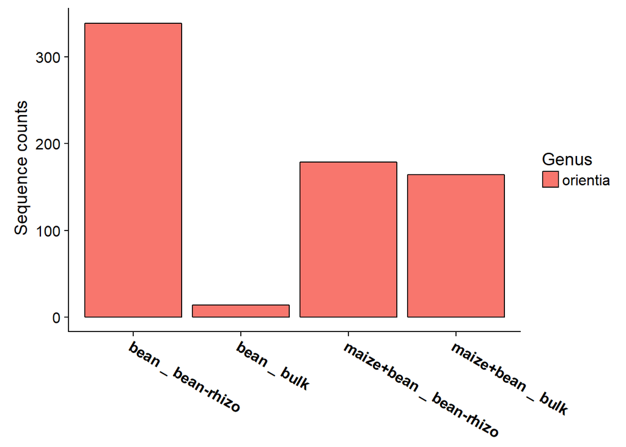

```r
be_ge_concom_ric %>%
  plot_bar(fill = "Genus",
         x = "concom")+
  theme(axis.text.x = element_text(angle = 330, size = 12, face = "bold"),
        axis.title.x = element_blank())+
  ylab(label = " Sequence counts")
```

And the same pattern is observed that for the Rickettsia family.

##### High variance

```r
mamomaco_gns_highVar0.5 =
  filter_taxa(mamomaco_gns,
              function(x) var(x) > 0.5, TRUE)

maize_gns_highVar0.5 <- as.data.frame (mamomaco_gns_highVar0.5@otu_table)

maize_gns_highVar0.5_sup15 <- maize_gns_highVar0.5[rowSums(maize_gns_highVar0.5) > 15,]

maize_gns_highVar0.5_sup15_max6 <- maize_gns_highVar0.5_sup15[rowSums(maize_gns_highVar0.5_sup15 ==0) <= 6,]

tax_maize_gns_highVar0.5_sup15_max6 <- subset(tax, rownames(tax) %in% rownames(maize_gns_highVar0.5_sup15_max6))

mmvsmc_hv_gns_s15m6 <- DESeqDataSetFromMatrix(maize_gns_highVar0.5_sup15_max6,
                                 meta_data_mamomaco,
                                 design = ~ culture)
mmvsmc_hv_gns_s15m6 <- DESeq(mmvsmc_hv_gns_s15m6)

mmvsmc_hv_gns_s15m6_res <- results(mmvsmc_hv_gns_s15m6, cooksCutoff = FALSE)

alpha = 0.05

gns_maize_hv_s15m6_sigtab = mmvsmc_hv_gns_s15m6_res[which(mmvsmc_hv_gns_s15m6_res$padj <= alpha), ]

gns_maize_hv_s15m6_sigtab
```

```
## log2 fold change (MLE): culture maize.bean vs maize
## Wald test p-value: culture maize.bean vs maize
## DataFrame with 1 row and 6 columns
##         baseMean log2FoldChange     lfcSE      stat       pvalue
##        <numeric>      <numeric> <numeric> <numeric>    <numeric>
## OTU198   64.1854       6.308936  1.598371  3.947104 7.910234e-05
##              padj
##         <numeric>
## OTU198 0.04089591
```

```r
gns_maize_hv_s15m6_sigtab_up <- gns_maize_hv_s15m6_sigtab[which(gns_maize_hv_s15m6_sigtab@listData$log2FoldChange > 0),]

cbind(head(gns_maize_hv_s15m6_sigtab_up[order(gns_maize_hv_s15m6_sigtab_up$padj),]), tax[row.names(head(gns_maize_hv_s15m6_sigtab_up[order(gns_maize_hv_s15m6_sigtab_up$padj),])),2:7])
```

```
## DataFrame with 1 row and 12 columns
##         baseMean log2FoldChange     lfcSE      stat       pvalue
##        <numeric>      <numeric> <numeric> <numeric>    <numeric>
## OTU198   64.1854       6.308936  1.598371  3.947104 7.910234e-05
##              padj         Phylum               Class         Order
##         <numeric>       <factor>            <factor>      <factor>
## OTU198 0.04089591 proteobacteria alphaproteobacteria rickettsiales
##                Family    Genus                Species
##              <factor> <factor>               <factor>
## OTU198 rickettsiaceae orientia orientia tsutsugamushi
```

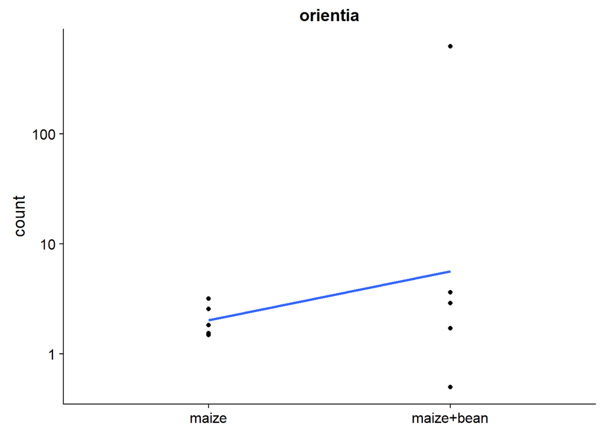

```r
plots.list <- lapply(row.names(head(gns_maize_hv_s15m6_sigtab_up[order(gns_maize_hv_s15m6_sigtab_up$padj),])),
                     function(x) {
                       d <- plotCounts(mmvsmc_hv_gns_s15m6, x, intgroup=c("culture"), returnData=TRUE)
                       ggplot(d, aes(x=culture, y=count, group=1)) +
                         geom_point() + stat_smooth(se=FALSE,method="loess") + scale_y_log10() +
                         ggtitle(tax[x,"Genus"]) +
                         theme(axis.title.x = element_blank(), legend.title=element_blank(), legend.position="top", legend.box="horizontal", legend.key.height = unit(.5, "cm"),legend.text=element_text(size=6))
                     }
)
do.call(grid.arrange,plots.list)
```

The result that without filtering.